# Regression Method/CI Analysis

Kayleigh Ryherd

10/26/2016

# 15/70 Confidence Intervals

## Table of Contents

1. Linear Model with WASI Vocab
   - Group Differences
2. Linear Model with PPVT
   - Group Differences
3. Linear Model with Vocabulary Composite
   - Group Differences
4. Linear Model with Oral Comprehension
   - Group Differences
5. Robust Model with WASI Vocab
   - Group Differences
6. Robust Model with PPVT
   - Group Differences
7. Robust Model with Vocabulary Composite
   - Group Differences
8. Robust Model with Oral Comprehension
   - Group Differences
9. Group Sizes

Read in packages & data.

```r
library(fBasics)
library(caret)
library(MASS)
library(ggplot2)
library(plyr)
library(reshape2)
library(xtable)
setwd("~/Dropbox/Definition_of_PCs/Sept2016")
data <- read.csv("FullDataDec15_2016.csv")
data <- data[,-1]
```

Define some functions.

```r
# for plotting
gg_color_hue <- function(n) {
  hues = seq(15, 375, length=n+1)
  hcl(h=hues, l=65, c=100)[1:n]
}

# CIs to z-scores
ci2z <- function(ci)
{
  qnorm(ci + (1 - ci)/2)
}
```

Choose your CIs.

```r
ci.to.use <- c(.15, .70)
ci.title <- "CIs: 15%, 70%"
```

## Linear Model with WASI Vocab

Run model, get groups.

```r
model.data.lmwv <- data[, c(1, 2, 18, 7, 6, 19, 11)]
lmwv.cc <- model.data.lmwv[complete.cases(model.data.lmwv),]
## Checking predictors, outcome
dagoTest(lmwv.cc$decoding.comp)
```

```
##
## Title:
##  D'Agostino Normality Test
##
## Test Results:
##   STATISTIC:
##     Chi2 | Omnibus: 2.6821
##     Z3  | Skewness: -1.6371
##     Z4  | Kurtosis: -0.0431
##   P VALUE:
##     Omnibus  Test: 0.2616
##     Skewness Test: 0.1016
##     Kurtosis Test: 0.9656
##
## Description:
##  Thu Dec 15 11:11:46 2016 by user:
```

```r
dagoTest(lmwv.cc$wasi.matr.raw)
```

```
##
## Title:
##  D'Agostino Normality Test
##
## Test Results:
##   STATISTIC:
##     Chi2 | Omnibus: 40.6696
##     Z3  | Skewness: -5.9786
##     Z4  | Kurtosis: 2.2196
##   P VALUE:
##     Omnibus  Test: 1.475e-09
##     Skewness Test: 2.251e-09
##     Kurtosis Test: 0.02645
##
## Description:
##  Thu Dec 15 11:11:46 2016 by user:
```

```r
dagoTest(lmwv.cc$wasi.vocab.raw)
```

```
##
## Title:
##  D'Agostino Normality Test
##
## Test Results:
##   STATISTIC:
##     Chi2 | Omnibus: 4.778
##     Z3  | Skewness: -1.1314
##     Z4  | Kurtosis: -1.8703
##   P VALUE:
##     Omnibus  Test: 0.09172
##     Skewness Test: 0.2579
##     Kurtosis Test: 0.06144
##
## Description:
##  Thu Dec 15 11:11:46 2016 by user:
```

```r
dagoTest(lmwv.cc$wj3.rcomp.raw)
```

```
##
## Title:
##  D'Agostino Normality Test
##
## Test Results:
##   STATISTIC:
##     Chi2 | Omnibus: 11.7216
##     Z3  | Skewness: -2.8249
##     Z4  | Kurtosis: -1.9343
##   P VALUE:
##     Omnibus  Test: 0.002849
##     Skewness Test: 0.00473
##     Kurtosis Test: 0.05308
##
## Description:
##  Thu Dec 15 11:11:46 2016 by user:
```

```r
## everything needs to be transformed except the decoding.comp, wasi vocab
vars_tf <- c("wasi.matr.raw", "wj3.rcomp.raw")
pp_md_tf <- preProcess(lmwv.cc[,vars_tf], method = c("center", "scale", "YeoJohnson"), na.remove=T)

#check the lambda values associated with the predictors
pp_md_tf$yj$wasi.matr.raw$lambda
```

```
##       Y1
## 2.633803
```

```r
pp_md_tf$yj$wj3.rcomp.raw$lambda
```

```
##      Y1
## 2.35728
```

```r
tf_data <- predict(pp_md_tf, lmwv.cc[,vars_tf])
lmwv.cc$wasi.matr.tf <- tf_data$wasi.matr.raw
lmwv.cc$wj3.rcomp.tf <- tf_data$wj3.rcomp.raw

dagoTest(lmwv.cc$wasi.matr.tf)
```

```
##
## Title:
##  D'Agostino Normality Test
##
## Test Results:
##   STATISTIC:
##     Chi2 | Omnibus: 12.3708
##     Z3  | Skewness: -1.0147
##     Z4  | Kurtosis: -3.3677
##   P VALUE:
##     Omnibus  Test: 0.002059
##     Skewness Test: 0.3103
##     Kurtosis Test: 0.000758
##
## Description:
##  Thu Dec 15 11:11:46 2016 by user:
```

```r
dagoTest(lmwv.cc$wj3.rcomp.tf)
```

```
##
## Title:
##  D'Agostino Normality Test
##
## Test Results:
##   STATISTIC:
##     Chi2 | Omnibus: 18.4071
##     Z3  | Skewness: -0.4836
##     Z4  | Kurtosis: -4.263
##   P VALUE:
##     Omnibus  Test: 0.0001007
##     Skewness Test: 0.6287
##     Kurtosis Test: 2.017e-05
##
## Description:
##  Thu Dec 15 11:11:46 2016 by user:
```

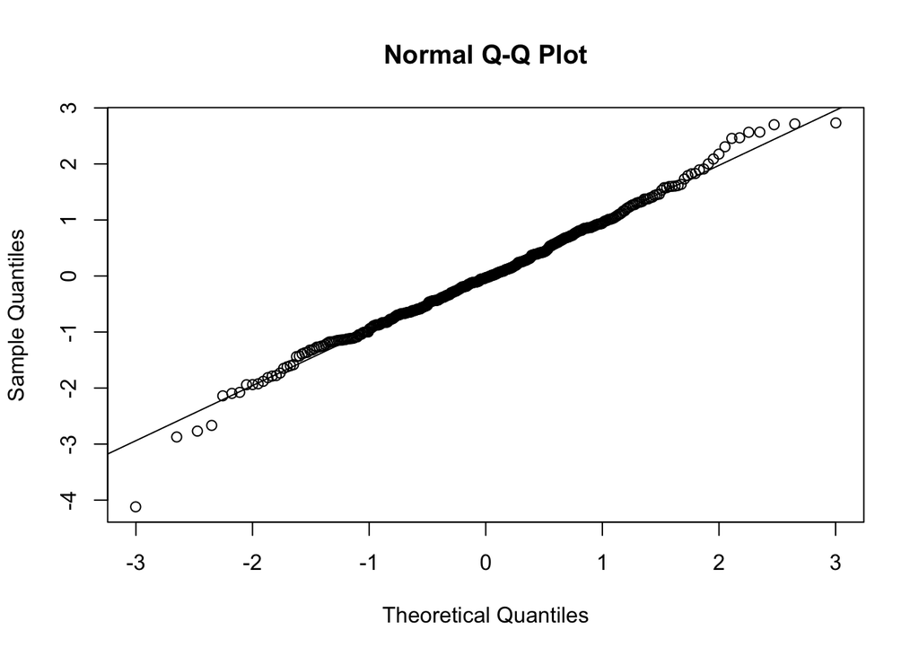

```r
# skewness has pretty much been fixed in all of them -- problem is just kurtosis

# center age
lmwv.cc$age.c <- lmwv.cc$age - mean(lmwv.cc$age, na.rm = TRUE)
# center/scale wasi vocab
lmwv.cc$wasi.vocab.cs <- scale(lmwv.cc$wasi.vocab.raw)
# composite has already been scaled

### Run regression
m1 <- lm(wj3.rcomp.tf ~ age.c + decoding.comp + wasi.matr.tf + wasi.vocab.cs, data = lmwv.cc)

#standardize predicted values
lmwv.cc$Pred <- predict(m1)
lmwv.cc$stdPred <- scale(lmwv.cc$Pred)

#obtained residuals
lmwv.cc$resid <- resid <- residuals(m1)
qqnorm(scale(resid)); qqline(scale(resid))
```

```r
#create the range of SD (z value) bins
my.bin <- c(range(scale(resid))+.1, ci2z(ci.to.use), -ci2z(ci.to.use))
#we could also manually specify in terms of SDs
# my.bin <- c(-3, -1, -.25, .25, 1, 3)
my.bin <- sort(my.bin)
# names for each bin specified above
grouping <- c("UPC", "NSC", "EAC", "NSC", "UGC")

lmwv.cc$CI_group <- grouping[findInterval(scale(resid), vec=my.bin, all.inside=T)]
#those with Standardized Predicted Value below -1 should be "EPC"
lmwv.cc$CI_group[lmwv.cc$stdPred < -1] <- "EPC"

### there are five groups c("EAC", "NSC", "UGC", "UPC", "EPC")
### so the argument n = 5
my.col <- gg_color_hue(n=5)

## unscale the z value for each CI, so I can add that value to intercept
unscale.ci <- my.bin[-c(1,length(my.bin))]*sd(resid)+mean(resid)

## create plot
m2 <- lm(wj3.rcomp.tf ~ stdPred, data=lmwv.cc)

p1 <- ggplot(lmwv.cc, aes(x=stdPred, y=wj3.rcomp.tf)) + geom_point(aes(color=CI_group)) +
  geom_abline(intercept = coef(m2)[1], slope = coef(m2)[2]) +
  geom_abline(intercept = coef(m2)[1] + unscale.ci[2], slope = coef(m2)[2], color=my.col[1]) +
  geom_abline(intercept = coef(m2)[1] + unscale.ci[3], slope = coef(m2)[2], color=my.col[1]) +
  geom_abline(intercept = coef(m2)[1] + unscale.ci[1], slope = coef(m2)[2], color=my.col[4]) +
  geom_abline(intercept = coef(m2)[1] + unscale.ci[4], slope = coef(m2)[2], color=my.col[3]) +
  geom_vline(xintercept = -1, lty="dotted") +
  xlab("Standardized Predicted Value")+ylab("WJ3 Reading Comprehension") +
  ggtitle(ci.title)
```

## Group Differences LM1

Linear Model with WASI vocab

```r
# take away NSC group
lmwv.cc2 <- subset(lmwv.cc, CI_group != "NSC")
lmwv.cc2$CI_group <- as.factor(lmwv.cc2$CI_group)
```

### Reading Comprehension

```r
a1 <- aov(wj3.rcomp.tf ~ CI_group, data = lmwv.cc2)
summary(a1)
```

```
##              Df Sum Sq Mean Sq F value Pr(>F)
## CI_group      3 177.82   59.27   153.6 <2e-16 ***
## Residuals   203  78.34    0.39
## ---
## Signif. codes:  0 '***' 0.001 '**' 0.01 '*' 0.05 '.' 0.1 ' ' 1
```

```r
pairwise.t.test(lmwv.cc2$wj3.rcomp.tf, lmwv.cc2$CI_group, p.adjust.method = "bonferroni")
```

```
##
##  Pairwise comparisons using t tests with pooled SD
##
## data:  lmwv.cc2$wj3.rcomp.tf and lmwv.cc2$CI_group
##
##     EAC     EPC     UGC
## EPC < 2e-16 -       -
## UGC 7.6e-11 < 2e-16 -
## UPC < 2e-16 0.41    < 2e-16
##
## P value adjustment method: bonferroni
```

```r
aggregate(lmwv.cc2$wj3.rcomp.tf, list(lmwv.cc2$CI_group), mean)
```

```
##   Group.1          x
## 1     EAC  0.3456891
## 2     EPC -1.0943486
## 3     UGC  1.2834047
## 4     UPC -0.8750771
```

### Age

```r
a1 <- aov(age.c ~ CI_group, data = lmwv.cc2)
summary(a1)
```

```
##              Df Sum Sq Mean Sq F value Pr(>F)
## CI_group      3  139.2   46.42   6.021  6e-04 ***
## Residuals   203 1565.0    7.71
## ---
## Signif. codes:  0 '***' 0.001 '**' 0.01 '*' 0.05 '.' 0.1 ' ' 1
```

```r
pairwise.t.test(lmwv.cc2$age.c, lmwv.cc2$CI_group, p.adjust.method = "bonferroni")
```

```
##
##  Pairwise comparisons using t tests with pooled SD
##
## data:  lmwv.cc2$age.c and lmwv.cc2$CI_group
##
##     EAC    EPC    UGC
## EPC 0.0074 -      -
## UGC 1.0000 0.0013 -
## UPC 1.0000 0.1941 0.7469
##
## P value adjustment method: bonferroni
```

```r
aggregate(lmwv.cc2$age.c, list(lmwv.cc2$CI_group), mean)
```

```
##   Group.1          x
## 1     EAC  0.3313996
## 2     EPC -1.3159073
## 3     UGC  0.7771403
## 4     UPC -0.1648294
```

### Matrix Reasoning

```r
a1 <- aov(wasi.matr.tf ~ CI_group, data = lmwv.cc2)
summary(a1)
```

```
##              Df Sum Sq Mean Sq F value Pr(>F)
## CI_group      3  75.53  25.175   36.64 <2e-16 ***
## Residuals   203 139.47   0.687
## ---
## Signif. codes:  0 '***' 0.001 '**' 0.01 '*' 0.05 '.' 0.1 ' ' 1
```

```r
pairwise.t.test(lmwv.cc2$wasi.matr.tf, lmwv.cc2$CI_group, p.adjust.method = "bonferroni")
```

```
##
##  Pairwise comparisons using t tests with pooled SD
##
## data:  lmwv.cc2$wasi.matr.tf and lmwv.cc2$CI_group
##
##     EAC     EPC     UGC
## EPC 5.0e-15 -       -
## UGC 1       2.7e-13 -
## UPC 1       7.5e-11 1
##
## P value adjustment method: bonferroni
```

```r
aggregate(lmwv.cc2$wasi.matr.tf, list(lmwv.cc2$CI_group), mean)
```

```
##   Group.1           x
## 1     EAC  0.21244899
## 2     EPC -1.10082764
## 3     UGC  0.24353246
## 4     UPC  0.04510091
```

### Decoding

```r
a1 <- aov(decoding.comp ~ CI_group, data = lmwv.cc2)
summary(a1)
```

```
##              Df Sum Sq Mean Sq F value Pr(>F)
## CI_group      3  101.5   33.82   51.77 <2e-16 ***
## Residuals   203  132.6    0.65
## ---
## Signif. codes:  0 '***' 0.001 '**' 0.01 '*' 0.05 '.' 0.1 ' ' 1
```

```r
pairwise.t.test(lmwv.cc2$decoding.comp, lmwv.cc2$CI_group, p.adjust.method = "bonferroni")
```

```
##
##  Pairwise comparisons using t tests with pooled SD
##
## data:  lmwv.cc2$decoding.comp and lmwv.cc2$CI_group
##
##     EAC     EPC     UGC
## EPC < 2e-16 -       -
## UGC 1       1.0e-15 -
## UPC 1       5.7e-16 1
##
## P value adjustment method: bonferroni
```

```r
aggregate(lmwv.cc2$decoding.comp, list(lmwv.cc2$CI_group), mean)
```

```
##   Group.1          x
## 1     EAC  0.4152683
## 2     EPC -1.1308146
## 3     UGC  0.3215621
## 4     UPC  0.2816014
```

### WASI Vocab

```r
a1 <- aov(wasi.vocab.cs ~ CI_group, data = lmwv.cc2)
summary(a1)
```

```
##              Df Sum Sq Mean Sq F value Pr(>F)
## CI_group      3  133.9   44.63   89.23 <2e-16 ***
## Residuals   203  101.5    0.50
## ---
## Signif. codes:  0 '***' 0.001 '**' 0.01 '*' 0.05 '.' 0.1 ' ' 1
```

```r
pairwise.t.test(lmwv.cc2$wasi.vocab.cs, lmwv.cc2$CI_group, p.adjust.method = "bonferroni")
```

```
##
##  Pairwise comparisons using t tests with pooled SD
##
## data:  lmwv.cc2$wasi.vocab.cs and lmwv.cc2$CI_group
##
##     EAC    EPC    UGC
## EPC <2e-16 -      -
## UGC 0.23   <2e-16 -
## UPC 0.23   <2e-16 1.00
##
## P value adjustment method: bonferroni
```

```r
aggregate(lmwv.cc2$wasi.vocab.cs, list(lmwv.cc2$CI_group), mean)
```

```
##   Group.1         V1
## 1     EAC  0.4881855
## 2     EPC -1.3767610
## 3     UGC  0.1779024
## 4     UPC  0.1892133
```

Show group sizes, plot.

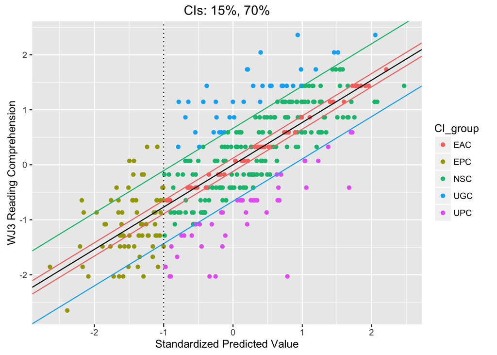

```r
print(p1)
```

```r
LM.WASI.Vocab <- data.frame(table(lmwv.cc$CI_group, lmwv.cc$handedness))
names(LM.WASI.Vocab) <- c("Group", "handedness", "lm.wasi.vocab")
LM.WASI.Vocab.r <- LM.WASI.Vocab[LM.WASI.Vocab$handedness == "right",]
LM.WASI.Vocab.r <- LM.WASI.Vocab.r[,-2]
```

## Linear Model with PPVT

Run model, get groups.

```r
model.data.lmpp <- data[, c(1, 2, 18, 7, 5, 19, 11)]
lmpp.cc <- model.data.lmpp[complete.cases(model.data.lmpp),]
## Checking predictors, outcome
dagoTest(lmpp.cc$decoding.comp)
```

```
##
## Title:
##  D'Agostino Normality Test
##
## Test Results:
##   STATISTIC:
##     Chi2 | Omnibus: 2.4569
##     Z3  | Skewness: -1.5674
##     Z4  | Kurtosis: -0.0185
##   P VALUE:
##     Omnibus  Test: 0.2927
##     Skewness Test: 0.117
##     Kurtosis Test: 0.9852
##
## Description:
##  Thu Dec 15 11:11:48 2016 by user:
```

```r
dagoTest(lmpp.cc$wasi.matr.raw)
```

```
##
## Title:
##  D'Agostino Normality Test
##
## Test Results:
##   STATISTIC:
##     Chi2 | Omnibus: 33.0189
##     Z3  | Skewness: -5.5468
##     Z4  | Kurtosis: 1.5006
##   P VALUE:
##     Omnibus  Test: 6.762e-08
##     Skewness Test: 2.91e-08
##     Kurtosis Test: 0.1334
##
## Description:
##  Thu Dec 15 11:11:48 2016 by user:
```

```r
dagoTest(lmpp.cc$ppvt.raw)
```

```
##
## Title:
##  D'Agostino Normality Test
##
## Test Results:
##   STATISTIC:
##     Chi2 | Omnibus: 44.9168
##     Z3  | Skewness: -6.5326
##     Z4  | Kurtosis: 1.4973
##   P VALUE:
##     Omnibus  Test: 1.764e-10
##     Skewness Test: 6.464e-11
##     Kurtosis Test: 0.1343
##
## Description:
##  Thu Dec 15 11:11:48 2016 by user:
```

```r
dagoTest(lmpp.cc$wj3.rcomp.raw)
```

```
##
## Title:
##  D'Agostino Normality Test
##
## Test Results:
##   STATISTIC:
##     Chi2 | Omnibus: 11.0493
##     Z3  | Skewness: -2.7966
##     Z4  | Kurtosis: -1.7968
##   P VALUE:
##     Omnibus  Test: 0.003987
##     Skewness Test: 0.005165
##     Kurtosis Test: 0.07237
##
## Description:
##  Thu Dec 15 11:11:48 2016 by user:
```

```r
## everything needs to be transformed except the decoding.comp
vars_tf <- c("wasi.matr.raw", "ppvt.raw", "wj3.rcomp.raw")
pp_md_tf <- preProcess(lmpp.cc[,vars_tf], method = c("center", "scale", "YeoJohnson"), na.remove=T)

#check the lambda values associated with the predictors
pp_md_tf$yj$wasi.matr.raw$lambda
```

```
##       Y1
## 2.616826
```

```r
pp_md_tf$yj$ppvt.raw$lambda
```

```
##       Y1
## 6.016183
```

```r
pp_md_tf$yj$wj3.rcomp.raw$lambda
```

```
##       Y1
## 2.360957
```

```r
tf_data <- predict(pp_md_tf, lmpp.cc[,vars_tf])
lmpp.cc$wasi.matr.tf <- tf_data$wasi.matr.raw
lmpp.cc$ppvt.tf <- tf_data$ppvt.raw
lmpp.cc$wj3.rcomp.tf <- tf_data$wj3.rcomp.raw

dagoTest(lmpp.cc$wasi.matr.tf)
```

```
##
## Title:
##  D'Agostino Normality Test
##
## Test Results:
##   STATISTIC:
##     Chi2 | Omnibus: 13.003
##     Z3  | Skewness: -0.9627
##     Z4  | Kurtosis: -3.4751
##   P VALUE:
##     Omnibus  Test: 0.001501
##     Skewness Test: 0.3357
##     Kurtosis Test: 0.0005107
##
## Description:
##  Thu Dec 15 11:11:48 2016 by user:
```

```r
dagoTest(lmpp.cc$ppvt.tf)
```

```
##
## Title:
##  D'Agostino Normality Test
##
## Test Results:
##   STATISTIC:
##     Chi2 | Omnibus: 25.5971
##     Z3  | Skewness: -1.2506
##     Z4  | Kurtosis: -4.9024
##   P VALUE:
##     Omnibus  Test: 2.765e-06
##     Skewness Test: 0.2111
##     Kurtosis Test: 9.469e-07
##
## Description:
##  Thu Dec 15 11:11:48 2016 by user:
```

```r
dagoTest(lmpp.cc$wj3.rcomp.tf)
```

```
##
## Title:
##  D'Agostino Normality Test
##
## Test Results:
##   STATISTIC:
##     Chi2 | Omnibus: 17.4166
##     Z3  | Skewness: -0.4659
##     Z4  | Kurtosis: -4.1472
##   P VALUE:
##     Omnibus  Test: 0.0001652
##     Skewness Test: 0.6413
##     Kurtosis Test: 3.365e-05
##
## Description:
##  Thu Dec 15 11:11:48 2016 by user:
```

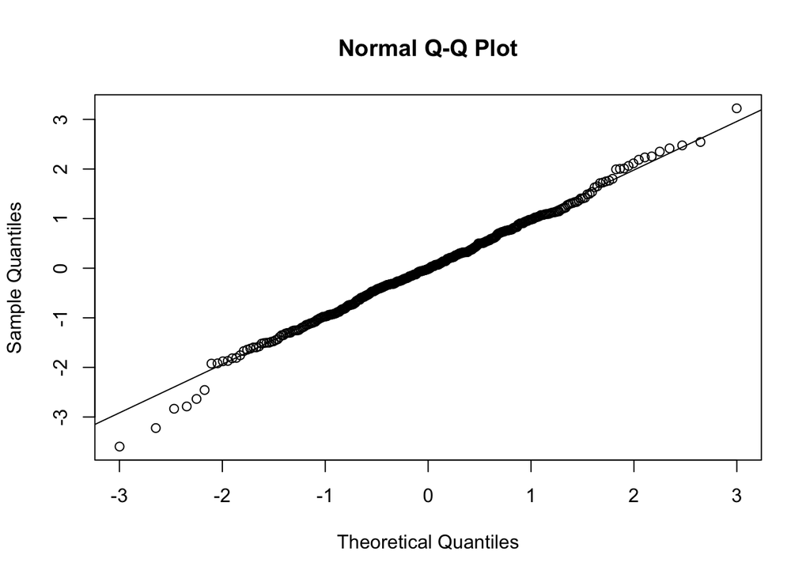

```r
# skewness has pretty much been fixed in all of them -- problem is just kurtosis

# center age
lmpp.cc$age.c <- lmpp.cc$age - mean(lmpp.cc$age, na.rm = TRUE)
# composite has already been scaled

### Run regression
m1 <- lm(wj3.rcomp.tf ~ age.c + decoding.comp + wasi.matr.tf + ppvt.tf, data = lmpp.cc)

#standardize predicted values
lmpp.cc$Pred <- predict(m1)
lmpp.cc$stdPred <- scale(lmpp.cc$Pred)

#obtained residuals
lmpp.cc$resid <- resid <- residuals(m1)
qqnorm(scale(resid)); qqline(scale(resid))
```

```r
#create the range of SD (z value) bins
my.bin <- c(range(scale(resid))+.1, ci2z(ci.to.use), -ci2z(ci.to.use))
#we could also manually specify in terms of SDs
# my.bin <- c(-3, -1, -.25, .25, 1, 3)
my.bin <- sort(my.bin)
# names for each bin specified above
grouping <- c("UPC", "NSC", "EAC", "NSC", "UGC")

lmpp.cc$CI_group <- grouping[findInterval(scale(resid), vec=my.bin, all.inside=T)]
#those with Standardized Predicted Value below -1 should be "EPC"
lmpp.cc$CI_group[lmpp.cc$stdPred < -1] <- "EPC"

### there are five groups c("EAC", "NSC", "UGC", "UPC", "EPC")
### so the argument n = 5
my.col <- gg_color_hue(n=5)

## unscale the z value for each CI, so I can add that value to intercept
unscale.ci <- my.bin[-c(1,length(my.bin))]*sd(resid)+mean(resid)

## create plot
m2 <- lm(wj3.rcomp.tf ~ stdPred, data=lmpp.cc)

p1 <- ggplot(lmpp.cc, aes(x=stdPred, y=wj3.rcomp.tf)) + geom_point(aes(color=CI_group)) +
  geom_abline(intercept = coef(m2)[1], slope = coef(m2)[2]) +
  geom_abline(intercept = coef(m2)[1] + unscale.ci[2], slope = coef(m2)[2], color=my.col[1]) +
  geom_abline(intercept = coef(m2)[1] + unscale.ci[3], slope = coef(m2)[2], color=my.col[1]) +
  geom_abline(intercept = coef(m2)[1] + unscale.ci[1], slope = coef(m2)[2], color=my.col[4]) +
  geom_abline(intercept = coef(m2)[1] + unscale.ci[4], slope = coef(m2)[2], color=my.col[3]) +
  geom_vline(xintercept = -1, lty="dotted") +
  xlab("Standardized Predicted Value")+ylab("WJ3 Reading Comprehension") +
  ggtitle(ci.title)
```

## Group Differences LM2

Linear Model with PPVT

```r
# take away NSC group
lmpp.cc2 <- subset(lmpp.cc, CI_group != "NSC")
lmpp.cc2$CI_group <- as.factor(lmpp.cc2$CI_group)
```

### Reading Comprehension

```r
a1 <- aov(wj3.rcomp.tf ~ CI_group, data = lmpp.cc2)
summary(a1)
```

```
##              Df Sum Sq Mean Sq F value Pr(>F)
## CI_group      3 185.43   61.81   189.5 <2e-16 ***
## Residuals   197  64.27    0.33
## ---
## Signif. codes:  0 '***' 0.001 '**' 0.01 '*' 0.05 '.' 0.1 ' ' 1
```

```r
pairwise.t.test(lmpp.cc2$wj3.rcomp.tf, lmpp.cc2$CI_group, p.adjust.method = "bonferroni")
```

```
##
##  Pairwise comparisons using t tests with pooled SD
##
## data:  lmpp.cc2$wj3.rcomp.tf and lmpp.cc2$CI_group
##
##     EAC     EPC     UGC
## EPC < 2e-16 -       -
## UGC 1.2e-10 < 2e-16 -
## UPC 1.2e-15 2.1e-05 < 2e-16
##
## P value adjustment method: bonferroni
```

```r
aggregate(lmpp.cc2$wj3.rcomp.tf, list(lmpp.cc2$CI_group), mean)
```

```
##   Group.1          x
## 1     EAC  0.3705825
## 2     EPC -1.2306869
## 3     UGC  1.2380015
## 4     UPC -0.7068431
```

### Age

```r
a1 <- aov(age.c ~ CI_group, data = lmpp.cc2)
summary(a1)
```

```
##              Df Sum Sq Mean Sq F value   Pr(>F)
## CI_group      3  157.3   52.44   6.494 0.000327 ***
## Residuals   197 1590.9    8.08
## ---
## Signif. codes:  0 '***' 0.001 '**' 0.01 '*' 0.05 '.' 0.1 ' ' 1
```

```r
pairwise.t.test(lmpp.cc2$age.c, lmpp.cc2$CI_group, p.adjust.method = "bonferroni")
```

```
##
##  Pairwise comparisons using t tests with pooled SD
##
## data:  lmpp.cc2$age.c and lmpp.cc2$CI_group
##
##     EAC    EPC    UGC
## EPC 0.0691 -      -
## UGC 1.0000 0.0039 -
## UPC 1.0000 0.0011 1.0000
##
## P value adjustment method: bonferroni
```

```r
aggregate(lmpp.cc2$age.c, list(lmpp.cc2$CI_group), mean)
```

```
##   Group.1            x
## 1     EAC -0.001758572
## 2     EPC -1.385345528
## 3     UGC  0.549297329
## 4     UPC  0.699376694
```

### Matrix Reasoning

```r
a1 <- aov(wasi.matr.tf ~ CI_group, data = lmpp.cc2)
summary(a1)
```

```
##              Df Sum Sq Mean Sq F value Pr(>F)
## CI_group      3  74.91  24.971   37.93 <2e-16 ***
## Residuals   197 129.70   0.658
## ---
## Signif. codes:  0 '***' 0.001 '**' 0.01 '*' 0.05 '.' 0.1 ' ' 1
```

```r
pairwise.t.test(lmpp.cc2$wasi.matr.tf, lmpp.cc2$CI_group, p.adjust.method = "bonferroni")
```

```
##
##  Pairwise comparisons using t tests with pooled SD
##
## data:  lmpp.cc2$wasi.matr.tf and lmpp.cc2$CI_group
##
##     EAC     EPC     UGC
## EPC < 2e-16 -       -
## UGC 0.85    9.5e-12 -
## UPC 0.35    5.0e-11 1.00
##
## P value adjustment method: bonferroni
```

```r
aggregate(lmpp.cc2$wasi.matr.tf, list(lmpp.cc2$CI_group), mean)
```

```
##   Group.1           x
## 1     EAC  0.38553096
## 2     EPC -1.07218720
## 3     UGC  0.13016113
## 4     UPC  0.06094368
```

### Decoding

```r
a1 <- aov(decoding.comp ~ CI_group, data = lmpp.cc2)
summary(a1)
```

```
##              Df Sum Sq Mean Sq F value Pr(>F)
## CI_group      3  94.02  31.341   54.27 <2e-16 ***
## Residuals   197 113.78   0.578
## ---
## Signif. codes:  0 '***' 0.001 '**' 0.01 '*' 0.05 '.' 0.1 ' ' 1
```

```r
pairwise.t.test(lmpp.cc2$decoding.comp, lmpp.cc2$CI_group, p.adjust.method = "bonferroni")
```

```
##
##  Pairwise comparisons using t tests with pooled SD
##
## data:  lmpp.cc2$decoding.comp and lmpp.cc2$CI_group
##
##     EAC     EPC     UGC
## EPC < 2e-16 -       -
## UGC 1       < 2e-16 -
## UPC 1       3.5e-16 1
##
## P value adjustment method: bonferroni
```

```r
aggregate(lmpp.cc2$decoding.comp, list(lmpp.cc2$CI_group), mean)
```

```
##   Group.1          x
## 1     EAC  0.4209957
## 2     EPC -1.0711223
## 3     UGC  0.4188313
## 4     UPC  0.2701827
```

### PPVT

```r
a1 <- aov(ppvt.tf ~ CI_group, data = lmpp.cc2)
summary(a1)
```

```
##              Df Sum Sq Mean Sq F value Pr(>F)
## CI_group      3 158.53   52.84   131.1 <2e-16 ***
## Residuals   197  79.38    0.40
## ---
## Signif. codes:  0 '***' 0.001 '**' 0.01 '*' 0.05 '.' 0.1 ' ' 1
```

```r
pairwise.t.test(lmpp.cc2$ppvt.tf, lmpp.cc2$CI_group, p.adjust.method = "bonferroni")
```

```
##
##  Pairwise comparisons using t tests with pooled SD
##
## data:  lmpp.cc2$ppvt.tf and lmpp.cc2$CI_group
##
##     EAC    EPC    UGC
## EPC <2e-16 -      -
## UGC 1      <2e-16 -
## UPC 1      <2e-16 1
##
## P value adjustment method: bonferroni
```

```r
aggregate(lmpp.cc2$ppvt.tf, list(lmpp.cc2$CI_group), mean)
```

```
##   Group.1          x
## 1     EAC  0.4736709
## 2     EPC -1.4847812
## 3     UGC  0.3492112
## 4     UPC  0.3403829
```

Show group sizes, plot.

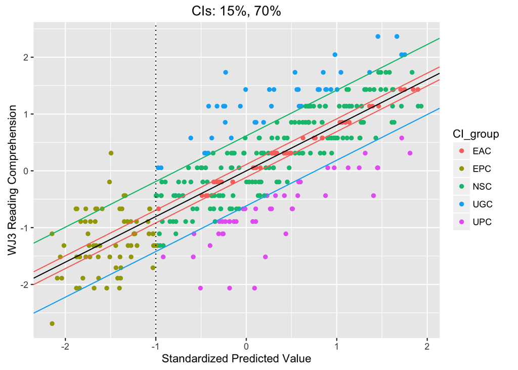

```r
print(p1)
```

```r
LM.PPVT <- data.frame(table(lmpp.cc$CI_group, lmpp.cc$handedness))
names(LM.PPVT) <- c("Group", "handedness", "lm.ppvt")
LM.PPVT.r <- LM.PPVT[LM.PPVT$handedness == "right",]
LM.PPVT.r <- LM.PPVT.r[,-2]
```

## Linear Model with Vocabulary Composite

Run model, get groups.

```r
model.data.lmvc <- data[, c(1, 2, 18, 7, 20, 19, 11)]
lmvc.cc <- model.data.lmvc[complete.cases(model.data.lmvc),]
## Checking predictors, outcome
dagoTest(lmvc.cc$decoding.comp)
```

```
##
## Title:
##  D'Agostino Normality Test
##
## Test Results:
##   STATISTIC:
##     Chi2 | Omnibus: 2.6821
##     Z3  | Skewness: -1.6371
##     Z4  | Kurtosis: -0.0431
##   P VALUE:
##     Omnibus  Test: 0.2616
##     Skewness Test: 0.1016
##     Kurtosis Test: 0.9656
##
## Description:
##  Thu Dec 15 11:11:49 2016 by user:
```

```r
dagoTest(lmvc.cc$wasi.matr.raw)
```

```
##
## Title:
##  D'Agostino Normality Test
##
## Test Results:
##   STATISTIC:
##     Chi2 | Omnibus: 40.6696
##     Z3  | Skewness: -5.9786
##     Z4  | Kurtosis: 2.2196
##   P VALUE:
##     Omnibus  Test: 1.475e-09
##     Skewness Test: 2.251e-09
##     Kurtosis Test: 0.02645
##
## Description:
##  Thu Dec 15 11:11:49 2016 by user:
```

```r
dagoTest(lmvc.cc$vocab.comp)
```

```
##
## Title:
##  D'Agostino Normality Test
##
## Test Results:
##   STATISTIC:
##     Chi2 | Omnibus: 17.6315
##     Z3  | Skewness: -1.5996
##     Z4  | Kurtosis: -3.8823
##   P VALUE:
##     Omnibus  Test: 0.0001484
##     Skewness Test: 0.1097
##     Kurtosis Test: 0.0001035
##
## Description:
##  Thu Dec 15 11:11:49 2016 by user:
```

```r
dagoTest(lmvc.cc$wj3.rcomp.raw)
```

```
##
## Title:
##  D'Agostino Normality Test
##
## Test Results:
##   STATISTIC:
##     Chi2 | Omnibus: 11.7216
##     Z3  | Skewness: -2.8249
##     Z4  | Kurtosis: -1.9343
##   P VALUE:
##     Omnibus  Test: 0.002849
##     Skewness Test: 0.00473
##     Kurtosis Test: 0.05308
##
## Description:
##  Thu Dec 15 11:11:49 2016 by user:
```

```r
## everything needs to be transformed except the decoding.comp, vocab comp
vars_tf <- c("wasi.matr.raw", "wj3.rcomp.raw")
pp_md_tf <- preProcess(lmvc.cc[,vars_tf], method = c("center", "scale", "YeoJohnson"), na.remove=T)

#check the lambda values associated with the predictors
pp_md_tf$yj$wasi.matr.raw$lambda
```

```
##       Y1
## 2.633803
```

```r
pp_md_tf$yj$vocab.comp$lambda
```

[output not shown]

```r
pp_md_tf$yj$wj3.rcomp.raw$lambda
```

```
##      Y1
## 2.35728
```

```r
tf_data <- predict(pp_md_tf, lmvc.cc[,vars_tf])
lmvc.cc$wasi.matr.tf <- tf_data$wasi.matr.raw
lmvc.cc$wj3.rcomp.tf <- tf_data$wj3.rcomp.raw

dagoTest(lmvc.cc$wasi.matr.tf)
```

```
##
## Title:
##  D'Agostino Normality Test
##
## Test Results:
##   STATISTIC:
##     Chi2 | Omnibus: 12.3708
##     Z3  | Skewness: -1.0147
##     Z4  | Kurtosis: -3.3677
##   P VALUE:
##     Omnibus  Test: 0.002059
##     Skewness Test: 0.3103
##     Kurtosis Test: 0.000758
##
## Description:
##  Thu Dec 15 11:11:50 2016 by user:
```

```r
dagoTest(lmvc.cc$wj3.rcomp.tf)
```

```
##
## Title:
##  D'Agostino Normality Test
##
## Test Results:
##   STATISTIC:
##     Chi2 | Omnibus: 18.4071
##     Z3  | Skewness: -0.4836
##     Z4  | Kurtosis: -4.263
##   P VALUE:
##     Omnibus  Test: 0.0001007
##     Skewness Test: 0.6287
##     Kurtosis Test: 2.017e-05
##
## Description:
##  Thu Dec 15 11:11:50 2016 by user:
```

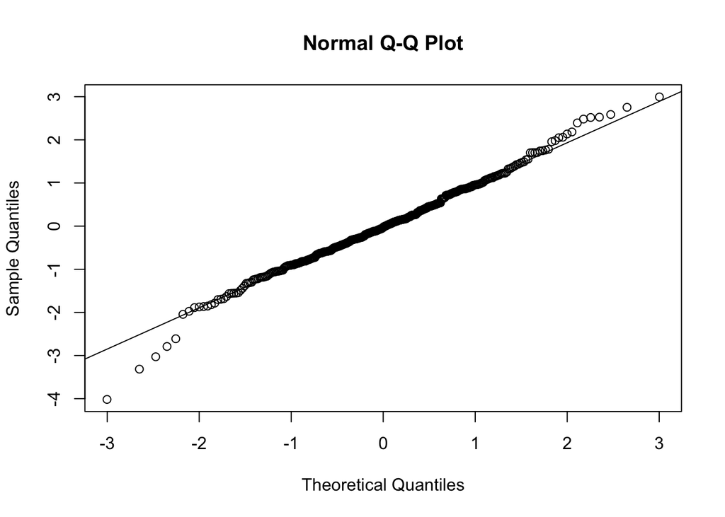

```r
# skewness has pretty much been fixed in all of them -- problem is just kurtosis

# center age
lmvc.cc$age.c <- lmvc.cc$age - mean(lmvc.cc$age, na.rm = TRUE)
# composites have already been scaled

### Run regression
m1 <- lm(wj3.rcomp.tf ~ age.c + decoding.comp + wasi.matr.tf + vocab.comp, data = lmvc.cc)

#standardize predicted values
lmvc.cc$Pred <- predict(m1)
lmvc.cc$stdPred <- scale(lmvc.cc$Pred)

#obtained residuals
lmvc.cc$resid <- resid <- residuals(m1)
qqnorm(scale(resid)); qqline(scale(resid))
```

```r
#create the range of SD (z value) bins
my.bin <- c(range(scale(resid))+.1, ci2z(ci.to.use), -ci2z(ci.to.use))
#we could also manually specify in terms of SDs
# my.bin <- c(-3, -1, -.25, .25, 1, 3)
my.bin <- sort(my.bin)
# names for each bin specified above
grouping <- c("UPC", "NSC", "EAC", "NSC", "UGC")

lmvc.cc$CI_group <- grouping[findInterval(scale(resid), vec=my.bin, all.inside=T)]
#those with Standardized Predicted Value below -1 should be "EPC"
lmvc.cc$CI_group[lmvc.cc$stdPred < -1] <- "EPC"

### there are five groups c("EAC", "NSC", "UGC", "UPC", "EPC")
### so the argument n = 5
my.col <- gg_color_hue(n=5)

## unscale the z value for each CI, so I can add that value to intercept
unscale.ci <- my.bin[-c(1,length(my.bin))]*sd(resid)+mean(resid)

## create plot
m2 <- lm(wj3.rcomp.tf ~ stdPred, data=lmvc.cc)

p1 <- ggplot(lmvc.cc, aes(x=stdPred, y=wj3.rcomp.tf)) + geom_point(aes(color=CI_group)) +
  geom_abline(intercept = coef(m2)[1], slope = coef(m2)[2]) +
  geom_abline(intercept = coef(m2)[1] + unscale.ci[2], slope = coef(m2)[2], color=my.col[1]) +
  geom_abline(intercept = coef(m2)[1] + unscale.ci[3], slope = coef(m2)[2], color=my.col[1]) +
  geom_abline(intercept = coef(m2)[1] + unscale.ci[1], slope = coef(m2)[2], color=my.col[4]) +
  geom_abline(intercept = coef(m2)[1] + unscale.ci[4], slope = coef(m2)[2], color=my.col[3]) +
  geom_vline(xintercept = -1, lty="dotted") +
  xlab("Standardized Predicted Value")+ylab("WJ3 Reading Comprehension") +
  ggtitle(ci.title)
```

## Group Differences LM3

Linear Model with Vocab Composite

```r
# take away NSC group
lmvc.cc2 <- subset(lmvc.cc, CI_group != "NSC")
lmvc.cc2$CI_group <- as.factor(lmvc.cc2$CI_group)
```

### Reading Comprehension

```r
a1 <- aov(wj3.rcomp.tf ~ CI_group, data = lmvc.cc2)
summary(a1)
```

```
##              Df Sum Sq Mean Sq F value Pr(>F)
## CI_group      3 179.64   59.88   157.2 <2e-16 ***
## Residuals   203  77.31    0.38
## ---
## Signif. codes:  0 '***' 0.001 '**' 0.01 '*' 0.05 '.' 0.1 ' ' 1
```

```r
pairwise.t.test(lmvc.cc2$wj3.rcomp.tf, lmvc.cc2$CI_group, p.adjust.method = "bonferroni")
```

```
##
##  Pairwise comparisons using t tests with pooled SD
##
## data:  lmvc.cc2$wj3.rcomp.tf and lmvc.cc2$CI_group
##
##     EAC     EPC     UGC
## EPC < 2e-16 -       -
## UGC 5.5e-11 < 2e-16 -
## UPC 2.0e-15 0.045   < 2e-16
##
## P value adjustment method: bonferroni
```

```r
aggregate(lmvc.cc2$wj3.rcomp.tf, list(lmvc.cc2$CI_group), mean)
```

```
##   Group.1          x
## 1     EAC  0.3174638
## 2     EPC -1.1539848
## 3     UGC  1.2560836
## 4     UPC -0.8269907
```

### Age

```r
a1 <- aov(age.c ~ CI_group, data = lmvc.cc2)
summary(a1)
```

```
##              Df Sum Sq Mean Sq F value Pr(>F)
## CI_group      3  122.1   40.72   4.997 0.0023 **
## Residuals   203 1654.0    8.15
## ---
## Signif. codes:  0 '***' 0.001 '**' 0.01 '*' 0.05 '.' 0.1 ' ' 1
```

```r
pairwise.t.test(lmvc.cc2$age.c, lmvc.cc2$CI_group, p.adjust.method = "bonferroni")
```

```
##
##  Pairwise comparisons using t tests with pooled SD
##
## data:  lmvc.cc2$age.c and lmvc.cc2$CI_group
##
##     EAC    EPC    UGC
## EPC 0.0044 -      -
## UGC 1.0000 0.0209 -
## UPC 1.0000 0.3334 1.0000
##
## P value adjustment method: bonferroni
```

```r
aggregate(lmvc.cc2$age.c, list(lmvc.cc2$CI_group), mean)
```

```
##   Group.1           x
## 1     EAC  0.61343660
## 2     EPC -1.13808492
## 3     UGC  0.53149928
## 4     UPC -0.05944303
```

### Matrix Reasoning

```r
a1 <- aov(wasi.matr.tf ~ CI_group, data = lmvc.cc2)
summary(a1)
```

```
##              Df Sum Sq Mean Sq F value Pr(>F)
## CI_group      3   66.6  22.202    33.5 <2e-16 ***
## Residuals   203  134.5   0.663
## ---
## Signif. codes:  0 '***' 0.001 '**' 0.01 '*' 0.05 '.' 0.1 ' ' 1
```

```r
pairwise.t.test(lmvc.cc2$wasi.matr.tf, lmvc.cc2$CI_group, p.adjust.method = "bonferroni")
```

```
##
##  Pairwise comparisons using t tests with pooled SD
##
## data:  lmvc.cc2$wasi.matr.tf and lmvc.cc2$CI_group
##
##     EAC     EPC     UGC
## EPC 1.5e-13 -       -
## UGC 1       7.4e-13 -
## UPC 1       4.4e-09 1
##
## P value adjustment method: bonferroni
```

```r
aggregate(lmvc.cc2$wasi.matr.tf, list(lmvc.cc2$CI_group), mean)
```

```
##   Group.1           x
## 1     EAC  0.14305988
## 2     EPC -1.05339982
## 3     UGC  0.22809376
## 4     UPC -0.02049737
```

### Decoding

```r
a1 <- aov(decoding.comp ~ CI_group, data = lmvc.cc2)
summary(a1)
```

```
##              Df Sum Sq Mean Sq F value Pr(>F)
## CI_group      3  91.03  30.344   49.23 <2e-16 ***
## Residuals   203 125.12   0.616
## ---
## Signif. codes:  0 '***' 0.001 '**' 0.01 '*' 0.05 '.' 0.1 ' ' 1
```

```r
pairwise.t.test(lmvc.cc2$decoding.comp, lmvc.cc2$CI_group, p.adjust.method = "bonferroni")
```

```
##
##  Pairwise comparisons using t tests with pooled SD
##
## data:  lmvc.cc2$decoding.comp and lmvc.cc2$CI_group
##
##     EAC     EPC     UGC
## EPC < 2e-16 -       -
## UGC 1       1.0e-15 -
## UPC 1       1.2e-15 1
##
## P value adjustment method: bonferroni
```

```r
aggregate(lmvc.cc2$decoding.comp, list(lmvc.cc2$CI_group), mean)
```

```
##   Group.1          x
## 1     EAC  0.2995951
## 2     EPC -1.0755462
## 3     UGC  0.3212376
## 4     UPC  0.3066625
```

### Vocab Composite

```r
a1 <- aov(vocab.comp ~ CI_group, data = lmvc.cc2)
summary(a1)
```

```
##              Df Sum Sq Mean Sq F value Pr(>F)
## CI_group      3 145.87   48.62   126.4 <2e-16 ***
## Residuals   203  78.11    0.38
## ---
## Signif. codes:  0 '***' 0.001 '**' 0.01 '*' 0.05 '.' 0.1 ' ' 1
```

```r
pairwise.t.test(lmvc.cc2$vocab.comp, lmvc.cc2$CI_group, p.adjust.method = "bonferroni")
```

```
##
##  Pairwise comparisons using t tests with pooled SD
##
## data:  lmvc.cc2$vocab.comp and lmvc.cc2$CI_group
##
##     EAC    EPC    UGC
## EPC <2e-16 -      -
## UGC 1.00   <2e-16 -
## UPC 0.65   <2e-16 1.00
##
## P value adjustment method: bonferroni
```

```r
aggregate(lmvc.cc2$vocab.comp, list(lmvc.cc2$CI_group), mean)
```

```
##   Group.1          x
## 1     EAC  0.4399855
## 2     EPC -1.3849275
## 3     UGC  0.3829026
## 4     UPC  0.2311524
```

Show group sizes, plot.

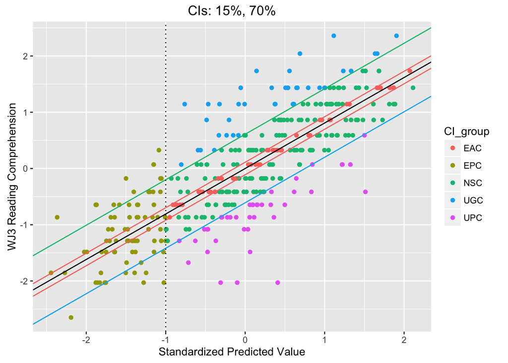

```r
print(p1)
```

```r
LM.VC <- data.frame(table(lmvc.cc$CI_group, lmvc.cc$handedness))
names(LM.VC) <- c("Group", "handedness", "lm.vocab.composite")
LM.VC.r <- LM.VC[LM.VC$handedness == "right",]
LM.VC.r <- LM.VC.r[,-2]
```

## Linear Model with Oral Comprehension

Run model, get groups.

```r
model.data.lmoc <- data[, c(1, 2, 18, 7, 12, 19, 11)]
lmoc.cc <- model.data.lmoc[complete.cases(model.data.lmoc),]
## Checking predictors, outcome
dagoTest(lmoc.cc$decoding.comp)
```

```
##
## Title:
##  D'Agostino Normality Test
##
## Test Results:
##   STATISTIC:
##     Chi2 | Omnibus: 2.9545
##     Z3  | Skewness: -1.7054
##     Z4  | Kurtosis: 0.2144
##   P VALUE:
##     Omnibus  Test: 0.2283
##     Skewness Test: 0.08811
##     Kurtosis Test: 0.8303
##
## Description:
##  Thu Dec 15 11:11:51 2016 by user:
```

```r
dagoTest(lmoc.cc$wasi.matr.raw)
```

```
##
## Title:
##  D'Agostino Normality Test
##
## Test Results:
##   STATISTIC:
##     Chi2 | Omnibus: 34.7557
##     Z3  | Skewness: -5.666
##     Z4  | Kurtosis: 1.6284
##   P VALUE:
##     Omnibus  Test: 2.837e-08
##     Skewness Test: 1.461e-08
##     Kurtosis Test: 0.1034
##
## Description:
##  Thu Dec 15 11:11:51 2016 by user:
```

```r
dagoTest(lmoc.cc$wj3.oralcomp.raw)
```

```
##
## Title:
##  D'Agostino Normality Test
##
## Test Results:
##   STATISTIC:
##     Chi2 | Omnibus: 18.373
##     Z3  | Skewness: -4.2378
##     Z4  | Kurtosis: -0.6433
##   P VALUE:
##     Omnibus  Test: 0.0001024
##     Skewness Test: 2.257e-05
##     Kurtosis Test: 0.52
##
## Description:
##  Thu Dec 15 11:11:51 2016 by user:
```

```r
dagoTest(lmoc.cc$wj3.rcomp.raw)
```

```
##
## Title:
##  D'Agostino Normality Test
##
## Test Results:
##   STATISTIC:
##     Chi2 | Omnibus: 10.6589
##     Z3  | Skewness: -2.9289
##     Z4  | Kurtosis: -1.4423
##   P VALUE:
##     Omnibus  Test: 0.004847
##     Skewness Test: 0.003401
##     Kurtosis Test: 0.1492
##
## Description:
##  Thu Dec 15 11:11:51 2016 by user:
```

```r
## everything needs to be transformed except the decoding.comp
vars_tf <- c("wasi.matr.raw", "wj3.oralcomp.raw", "wj3.rcomp.raw")
pp_md_tf <- preProcess(lmoc.cc[,vars_tf], method = c("center", "scale", "YeoJohnson"), na.remove=T)

#check the lambda values associated with the predictors
pp_md_tf$yj$wasi.matr.raw$lambda
```

```
##       Y1
## 2.660355
```

```r
pp_md_tf$yj$wj3.oralcomp$lambda
```

```
##       Y1
## 2.951652
```

```r
pp_md_tf$yj$wj3.rcomp.raw$lambda
```

```
##       Y1
## 2.425642
```

```r
tf_data <- predict(pp_md_tf, lmoc.cc[,vars_tf])
lmoc.cc$wasi.matr.tf <- tf_data$wasi.matr.raw
lmoc.cc$wj3.oralcomp.tf <- tf_data$wj3.oralcomp.raw
lmoc.cc$wj3.rcomp.tf <- tf_data$wj3.rcomp.raw

dagoTest(lmoc.cc$wasi.matr.tf)
```

```
##
## Title:
##  D'Agostino Normality Test
##
## Test Results:
##   STATISTIC:
##     Chi2 | Omnibus: 12.0458
##     Z3  | Skewness: -0.9779
##     Z4  | Kurtosis: -3.3301
##   P VALUE:
##     Omnibus  Test: 0.002423
##     Skewness Test: 0.3281
##     Kurtosis Test: 0.0008682
##
## Description:
##  Thu Dec 15 11:11:51 2016 by user:
```

```r
dagoTest(lmoc.cc$wj3.oralcomp.tf)
```

```
##
## Title:
##  D'Agostino Normality Test
##
## Test Results:
##   STATISTIC:
##     Chi2 | Omnibus: 16.5176
##     Z3  | Skewness: -0.7161
##     Z4  | Kurtosis: -4.0006
##   P VALUE:
##     Omnibus  Test: 0.000259
##     Skewness Test: 0.4739
##     Kurtosis Test: 6.318e-05
##
## Description:
##  Thu Dec 15 11:11:51 2016 by user:
```

```r
dagoTest(lmoc.cc$wj3.rcomp.tf)
```

```
##
## Title:
##  D'Agostino Normality Test
##
## Test Results:
##   STATISTIC:
##     Chi2 | Omnibus: 15.621
##     Z3  | Skewness: -0.4598
##     Z4  | Kurtosis: -3.9255
##   P VALUE:
##     Omnibus  Test: 0.0004055
##     Skewness Test: 0.6457
##     Kurtosis Test: 8.655e-05
##
## Description:
##  Thu Dec 15 11:11:51 2016 by user:
```

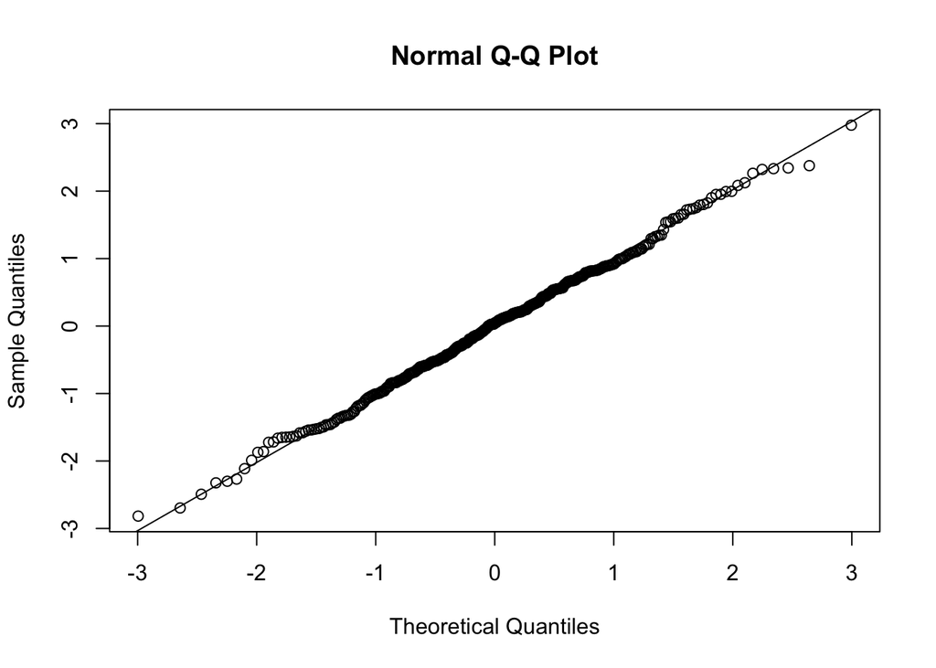

```r
# skewness has pretty much been fixed in all of them -- problem is just kurtosis

# center age
lmoc.cc$age.c <- lmoc.cc$age - mean(lmoc.cc$age, na.rm = TRUE)
# composite has already been scaled

### Run regression
m1 <- lm(wj3.rcomp.tf ~ age.c + decoding.comp + wasi.matr.tf + wj3.oralcomp.tf, data = lmoc.cc)

#standardize predicted values
lmoc.cc$Pred <- predict(m1)
lmoc.cc$stdPred <- scale(lmoc.cc$Pred)

#obtained residuals
lmoc.cc$resid <- resid <- residuals(m1)
qqnorm(scale(resid)); qqline(scale(resid))
```

```r
#create the range of SD (z value) bins
my.bin <- c(range(scale(resid))+.1, ci2z(ci.to.use), -ci2z(ci.to.use))
#we could also manually specify in terms of SDs
# my.bin <- c(-3, -1, -.25, .25, 1, 3)
my.bin <- sort(my.bin)
# names for each bin specified above
grouping <- c("UPC", "NSC", "EAC", "NSC", "UGC")

lmoc.cc$CI_group <- grouping[findInterval(scale(resid), vec=my.bin, all.inside=T)]
#those with Standardized Predicted Value below -1 should be "EPC"
lmoc.cc$CI_group[lmoc.cc$stdPred < -1] <- "EPC"

### there are five groups c("EAC", "NSC", "UGC", "UPC", "EPC")
### so the argument n = 5
my.col <- gg_color_hue(n=5)

## unscale the z value for each CI, so I can add that value to intercept
unscale.ci <- my.bin[-c(1,length(my.bin))]*sd(resid)+mean(resid)

## create plot
m2 <- lm(wj3.rcomp.tf ~ stdPred, data=lmoc.cc)

p1 <- ggplot(lmoc.cc, aes(x=stdPred, y=wj3.rcomp.tf)) + geom_point(aes(color=CI_group)) +
  geom_abline(intercept = coef(m2)[1], slope = coef(m2)[2]) +
  geom_abline(intercept = coef(m2)[1] + unscale.ci[2], slope = coef(m2)[2], color=my.col[1]) +
  geom_abline(intercept = coef(m2)[1] + unscale.ci[3], slope = coef(m2)[2], color=my.col[1]) +
  geom_abline(intercept = coef(m2)[1] + unscale.ci[1], slope = coef(m2)[2], color=my.col[4]) +
  geom_abline(intercept = coef(m2)[1] + unscale.ci[4], slope = coef(m2)[2], color=my.col[3]) +
  geom_vline(xintercept = -1, lty="dotted") +
  xlab("Standardized Predicted Value")+ylab("WJ3 Reading Comprehension") +
  ggtitle(ci.title)
```

## Group Differences LM4

Linear Model with Oral Comprehension

```r
# take away NSC group
lmoc.cc2 <- subset(lmoc.cc, CI_group != "NSC")
lmoc.cc2$CI_group <- as.factor(lmoc.cc2$CI_group)
```

### Reading Comprehension

```r
a1 <- aov(wj3.rcomp.tf ~ CI_group, data = lmoc.cc2)
summary(a1)
```

```
##              Df Sum Sq Mean Sq F value Pr(>F)
## CI_group      3 155.12   51.71   130.7 <2e-16 ***
## Residuals   188  74.38    0.40
## ---
## Signif. codes:  0 '***' 0.001 '**' 0.01 '*' 0.05 '.' 0.1 ' ' 1
```

```r
pairwise.t.test(lmoc.cc2$wj3.rcomp.tf, lmoc.cc2$CI_group, p.adjust.method = "bonferroni")
```

```
##
##  Pairwise comparisons using t tests with pooled SD
##
## data:  lmoc.cc2$wj3.rcomp.tf and lmoc.cc2$CI_group
##
##     EAC     EPC     UGC
## EPC < 2e-16 -       -
## UGC 1.3e-08 < 2e-16 -
## UPC 2.4e-11 0.00071 < 2e-16
##
## P value adjustment method: bonferroni
```

```r
aggregate(lmoc.cc2$wj3.rcomp.tf, list(lmoc.cc2$CI_group), mean)
```

```
##   Group.1          x
## 1     EAC  0.2826249
## 2     EPC -1.1888045
## 3     UGC  1.1701469
## 4     UPC -0.7120579
```

### Age

```r
a1 <- aov(age.c ~ CI_group, data = lmoc.cc2)
summary(a1)
```

```
##              Df Sum Sq Mean Sq F value Pr(>F)
## CI_group      3     78  25.999   3.436  0.018 *
## Residuals   188   1423   7.567
## ---
## Signif. codes:  0 '***' 0.001 '**' 0.01 '*' 0.05 '.' 0.1 ' ' 1
```

```r
pairwise.t.test(lmoc.cc2$age.c, lmoc.cc2$CI_group, p.adjust.method = "bonferroni")
```

```
##
##  Pairwise comparisons using t tests with pooled SD
##
## data:  lmoc.cc2$age.c and lmoc.cc2$CI_group
##
##     EAC   EPC   UGC
## EPC 0.347 -     -
## UGC 1.000 0.029 -
## UPC 1.000 0.115 1.000
##
## P value adjustment method: bonferroni
```

```r
aggregate(lmoc.cc2$age.c, list(lmoc.cc2$CI_group), mean)
```

```
##   Group.1            x
## 1     EAC -0.235070405
## 2     EPC -1.260794112
## 3     UGC  0.343534247
## 4     UPC -0.008910198
```

### Matrix Reasoning

```r
a1 <- aov(wasi.matr.tf ~ CI_group, data = lmoc.cc2)
summary(a1)
```

```
##              Df Sum Sq Mean Sq F value Pr(>F)
## CI_group      3  74.39  24.796    40.6 <2e-16 ***
## Residuals   188 114.81   0.611
## ---
## Signif. codes:  0 '***' 0.001 '**' 0.01 '*' 0.05 '.' 0.1 ' ' 1
```

```r
pairwise.t.test(lmoc.cc2$wasi.matr.tf, lmoc.cc2$CI_group, p.adjust.method = "bonferroni")
```

```
##
##  Pairwise comparisons using t tests with pooled SD
##
## data:  lmoc.cc2$wasi.matr.tf and lmoc.cc2$CI_group
##
##     EAC     EPC     UGC
## EPC 5.2e-14 -       -
## UGC 1       1.7e-13 -
## UPC 1       9.4e-15 1
##
## P value adjustment method: bonferroni
```

```r
aggregate(lmoc.cc2$wasi.matr.tf, list(lmoc.cc2$CI_group), mean)
```

```
##   Group.1          x
## 1     EAC  0.1444667
## 2     EPC -1.1436493
## 3     UGC  0.1752867
## 4     UPC  0.1680073
```

### Decoding

```r
a1 <- aov(decoding.comp ~ CI_group, data = lmoc.cc2)
summary(a1)
```

```
##              Df Sum Sq Mean Sq F value Pr(>F)
## CI_group      3  88.68   29.56   47.71 <2e-16 ***
## Residuals   188 116.49    0.62
## ---
## Signif. codes:  0 '***' 0.001 '**' 0.01 '*' 0.05 '.' 0.1 ' ' 1
```

```r
pairwise.t.test(lmoc.cc2$decoding.comp, lmoc.cc2$CI_group, p.adjust.method = "bonferroni")
```

```
##
##  Pairwise comparisons using t tests with pooled SD
##
## data:  lmoc.cc2$decoding.comp and lmoc.cc2$CI_group
##
##     EAC     EPC     UGC
## EPC < 2e-16 -       -
## UGC 1       1.1e-14 -
## UPC 1       < 2e-16 1
##
## P value adjustment method: bonferroni
```

```r
aggregate(lmoc.cc2$decoding.comp, list(lmoc.cc2$CI_group), mean)
```

```
##   Group.1          x
## 1     EAC  0.3196328
## 2     EPC -1.1192768
## 3     UGC  0.2812899
## 4     UPC  0.3141238
```

### Oral Comprehension

```r
a1 <- aov(wj3.oralcomp.tf ~ CI_group, data = lmoc.cc2)
summary(a1)
```

```
##              Df Sum Sq Mean Sq F value Pr(>F)
## CI_group      3 125.86   41.95   83.14 <2e-16 ***
## Residuals   188  94.87    0.50
## ---
## Signif. codes:  0 '***' 0.001 '**' 0.01 '*' 0.05 '.' 0.1 ' ' 1
```

```r
pairwise.t.test(lmoc.cc2$wj3.oralcomp.tf, lmoc.cc2$CI_group, p.adjust.method = "bonferroni")
```

```
##
##  Pairwise comparisons using t tests with pooled SD
##
## data:  lmoc.cc2$wj3.oralcomp.tf and lmoc.cc2$CI_group
##
##     EAC    EPC    UGC
## EPC <2e-16 -      -
## UGC 1      <2e-16 -
## UPC 1      <2e-16 1
##
## P value adjustment method: bonferroni
```

```r
aggregate(lmoc.cc2$wj3.oralcomp.tf, list(lmoc.cc2$CI_group), mean)
```

```
##   Group.1          x
## 1     EAC  0.4053831
## 2     EPC -1.3879019
## 3     UGC  0.2196616
## 4     UPC  0.2814785
```

Show group sizes, plot.

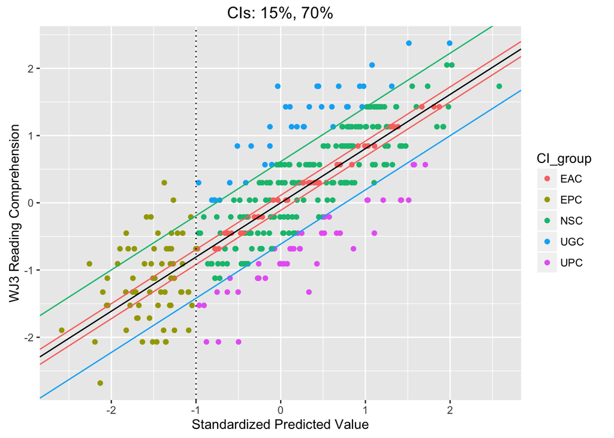

```r
print(p1)
```

```r
LM.OC <- data.frame(table(lmoc.cc$CI_group, lmoc.cc$handedness))
names(LM.OC) <- c("Group", "handedness", "lm.oralcomp")
LM.OC.r <- LM.OC[LM.OC$handedness == "right",]
LM.OC.r <- LM.OC.r[,-2]
```

## Robust Model with WASI Vocab

Run model, get groups.

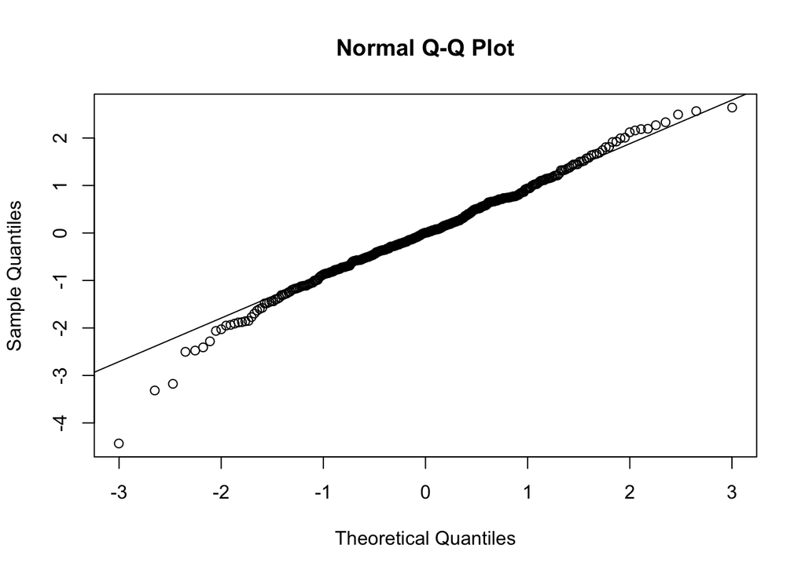

```r
model.data.rlmwv <- data[, c(1, 2, 18, 7, 6, 19, 11)]
rlmwv.cc <- model.data.rlmwv[complete.cases(model.data.rlmwv),]

# center and scale predictors
rlmwv.cc$wasi.matr.cs <- scale(rlmwv.cc$wasi.matr.raw)
rlmwv.cc$wasi.vocab.cs <- scale(rlmwv.cc$wasi.vocab.raw)
rlmwv.cc$wj3.rcomp.cs <- scale(rlmwv.cc$wj3.rcomp.raw)

# center age
rlmwv.cc$age.c <- rlmwv.cc$age - mean(rlmwv.cc$age, na.rm = TRUE)
# composite has already been scaled

### Run regression
m1 <- rlm(wj3.rcomp.cs ~ age.c + decoding.comp + wasi.matr.cs + wasi.vocab.cs, data = rlmwv.cc, method = "MM")

#standardize predicted values
rlmwv.cc$Pred <- predict(m1)
rlmwv.cc$stdPred <- scale(rlmwv.cc$Pred)

#obtained residuals
rlmwv.cc$resid <- resid <- residuals(m1)
qqnorm(scale(resid)); qqline(scale(resid))
```

```r
#create the range of SD (z value) bins
my.bin <- c(range(scale(resid))+.1, ci2z(ci.to.use), -ci2z(ci.to.use))
#we could also manually specify in terms of SDs
# my.bin <- c(-3, -1, -.25, .25, 1, 3)
my.bin <- sort(my.bin)
# names for each bin specified above
grouping <- c("UPC", "NSC", "EAC", "NSC", "UGC")

rlmwv.cc$CI_group <- grouping[findInterval(scale(resid), vec=my.bin, all.inside=T)]
#those with Standardized Predicted Value below -1 should be "EPC"
rlmwv.cc$CI_group[rlmwv.cc$stdPred < -1] <- "EPC"

### there are five groups c("EAC", "NSC", "UGC", "UPC", "EPC")
### so the argument n = 5
my.col <- gg_color_hue(n=5)

## unscale the z value for each CI, so I can add that value to intercept
unscale.ci <- my.bin[-c(1,length(my.bin))]*sd(resid)+mean(resid)

## create plot
m2 <- lm(wj3.rcomp.cs ~ stdPred, data=rlmwv.cc)

p1 <- ggplot(rlmwv.cc, aes(x=stdPred, y=wj3.rcomp.cs)) + geom_point(aes(color=CI_group)) +
  geom_abline(intercept = coef(m2)[1], slope = coef(m2)[2]) +
  geom_abline(intercept = coef(m2)[1] + unscale.ci[2], slope = coef(m2)[2], color=my.col[1]) +
  geom_abline(intercept = coef(m2)[1] + unscale.ci[3], slope = coef(m2)[2], color=my.col[1]) +
  geom_abline(intercept = coef(m2)[1] + unscale.ci[1], slope = coef(m2)[2], color=my.col[4]) +
  geom_abline(intercept = coef(m2)[1] + unscale.ci[4], slope = coef(m2)[2], color=my.col[3]) +
  geom_vline(xintercept = -1, lty="dotted") +
  xlab("Standardized Predicted Value")+ylab("WJ3 Reading Comprehension") +
  ggtitle(ci.title)
```

## Group Differences RLM1

Robust Model with WASI Vocab

```r
# take away NSC group
rlmwv.cc2 <- subset(rlmwv.cc, CI_group != "NSC")
rlmwv.cc2$CI_group <- as.factor(rlmwv.cc2$CI_group)
```

### Reading Comprehension

```r
a1 <- aov(wj3.rcomp.cs ~ CI_group, data = rlmwv.cc2)
summary(a1)
```

```
##              Df Sum Sq Mean Sq F value Pr(>F)
## CI_group      3 163.86   54.62   123.5 <2e-16 ***
## Residuals   195  86.24    0.44
## ---
## Signif. codes:  0 '***' 0.001 '**' 0.01 '*' 0.05 '.' 0.1 ' ' 1
```

```r
pairwise.t.test(rlmwv.cc2$wj3.rcomp.cs, rlmwv.cc2$CI_group, p.adjust.method = "bonferroni")
```

```
##
##  Pairwise comparisons using t tests with pooled SD
##
## data:  rlmwv.cc2$wj3.rcomp.cs and rlmwv.cc2$CI_group
##
##     EAC     EPC     UGC
## EPC < 2e-16 -       -
## UGC 3.8e-07 < 2e-16 -
## UPC < 2e-16 1       < 2e-16
##
## P value adjustment method: bonferroni
```

```r
aggregate(rlmwv.cc2$wj3.rcomp.cs, list(rlmwv.cc2$CI_group), mean)
```

```
##   Group.1         V1
## 1     EAC  0.3487528
## 2     EPC -1.1293570
## 3     UGC  1.1511355
## 4     UPC -0.9707429
```

### Age

```r
a1 <- aov(age.c ~ CI_group, data = rlmwv.cc2)
summary(a1)
```

```
##              Df Sum Sq Mean Sq F value Pr(>F)
## CI_group      3  121.7   40.56   5.189 0.0018 **
## Residuals   195 1524.3    7.82
## ---
## Signif. codes:  0 '***' 0.001 '**' 0.01 '*' 0.05 '.' 0.1 ' ' 1
```

```r
pairwise.t.test(rlmwv.cc2$age.c, rlmwv.cc2$CI_group, p.adjust.method = "bonferroni")
```

```
##
##  Pairwise comparisons using t tests with pooled SD
##
## data:  rlmwv.cc2$age.c and rlmwv.cc2$CI_group
##
##     EAC    EPC    UGC
## EPC 0.0145 -      -
## UGC 1.0000 0.0038 -
## UPC 1.0000 0.5699 0.6198
##
## P value adjustment method: bonferroni
```

```r
aggregate(rlmwv.cc2$age.c, list(rlmwv.cc2$CI_group), mean)
```

```
##   Group.1          x
## 1     EAC  0.2159888
## 2     EPC -1.3374974
## 3     UGC  0.6599181
## 4     UPC -0.3977315
```

### Matrix Reasoning

```r
a1 <- aov(wasi.matr.cs ~ CI_group, data = rlmwv.cc2)
summary(a1)
```

```
##              Df Sum Sq Mean Sq F value Pr(>F)
## CI_group      3   73.8  24.599   34.78 <2e-16 ***
## Residuals   195  137.9   0.707
## ---
## Signif. codes:  0 '***' 0.001 '**' 0.01 '*' 0.05 '.' 0.1 ' ' 1
```

```r
pairwise.t.test(rlmwv.cc2$wasi.matr.cs, rlmwv.cc2$CI_group, p.adjust.method = "bonferroni")
```

```
##
##  Pairwise comparisons using t tests with pooled SD
##
## data:  rlmwv.cc2$wasi.matr.cs and rlmwv.cc2$CI_group
##
##     EAC     EPC     UGC
## EPC 1.6e-15 -       -
## UGC 1.00    1.1e-11 -
## UPC 0.79    3.9e-09 1.00
##
## P value adjustment method: bonferroni
```

```r
aggregate(rlmwv.cc2$wasi.matr.cs, list(rlmwv.cc2$CI_group), mean)
```

```
##   Group.1          V1
## 1     EAC  0.23398588
## 2     EPC -1.12735755
## 3     UGC  0.17396782
## 4     UPC -0.03223775
```

### Decoding

```r
a1 <- aov(decoding.comp ~ CI_group, data = rlmwv.cc2)
summary(a1)
```

```
##              Df Sum Sq Mean Sq F value Pr(>F)
## CI_group      3  93.12  31.040   45.91 <2e-16 ***
## Residuals   195 131.83   0.676
## ---
## Signif. codes:  0 '***' 0.001 '**' 0.01 '*' 0.05 '.' 0.1 ' ' 1
```

```r
pairwise.t.test(rlmwv.cc2$decoding.comp, rlmwv.cc2$CI_group, p.adjust.method = "bonferroni")
```

```
##
##  Pairwise comparisons using t tests with pooled SD
##
## data:  rlmwv.cc2$decoding.comp and rlmwv.cc2$CI_group
##
##     EAC     EPC     UGC
## EPC < 2e-16 -       -
## UGC 1       2.9e-13 -
## UPC 1       3.9e-14 1
##
## P value adjustment method: bonferroni
```

```r
aggregate(rlmwv.cc2$decoding.comp, list(rlmwv.cc2$CI_group), mean)
```

```
##   Group.1          x
## 1     EAC  0.3629807
## 2     EPC -1.1391443
## 3     UGC  0.2353973
## 4     UPC  0.2531366
```

### WASI Vocab

```r
a1 <- aov(wasi.vocab.cs ~ CI_group, data = rlmwv.cc2)
summary(a1)
```

```
##              Df Sum Sq Mean Sq F value Pr(>F)
## CI_group      3 133.65   44.55   90.17 <2e-16 ***
## Residuals   195  96.35    0.49
## ---
## Signif. codes:  0 '***' 0.001 '**' 0.01 '*' 0.05 '.' 0.1 ' ' 1
```

```r
pairwise.t.test(rlmwv.cc2$wasi.vocab.cs, rlmwv.cc2$CI_group, p.adjust.method = "bonferroni")
```

```
##
##  Pairwise comparisons using t tests with pooled SD
##
## data:  rlmwv.cc2$wasi.vocab.cs and rlmwv.cc2$CI_group
##
##     EAC    EPC    UGC
## EPC <2e-16 -      -
## UGC 0.019  <2e-16 -
## UPC 0.256  <2e-16 1.000
##
## P value adjustment method: bonferroni
```

```r
aggregate(rlmwv.cc2$wasi.vocab.cs, list(rlmwv.cc2$CI_group), mean)
```

```
##   Group.1         V1
## 1     EAC  0.5036578
## 2     EPC -1.4016967
## 3     UGC  0.0534819
## 4     UPC  0.2034245
```

Show group sizes, plot.

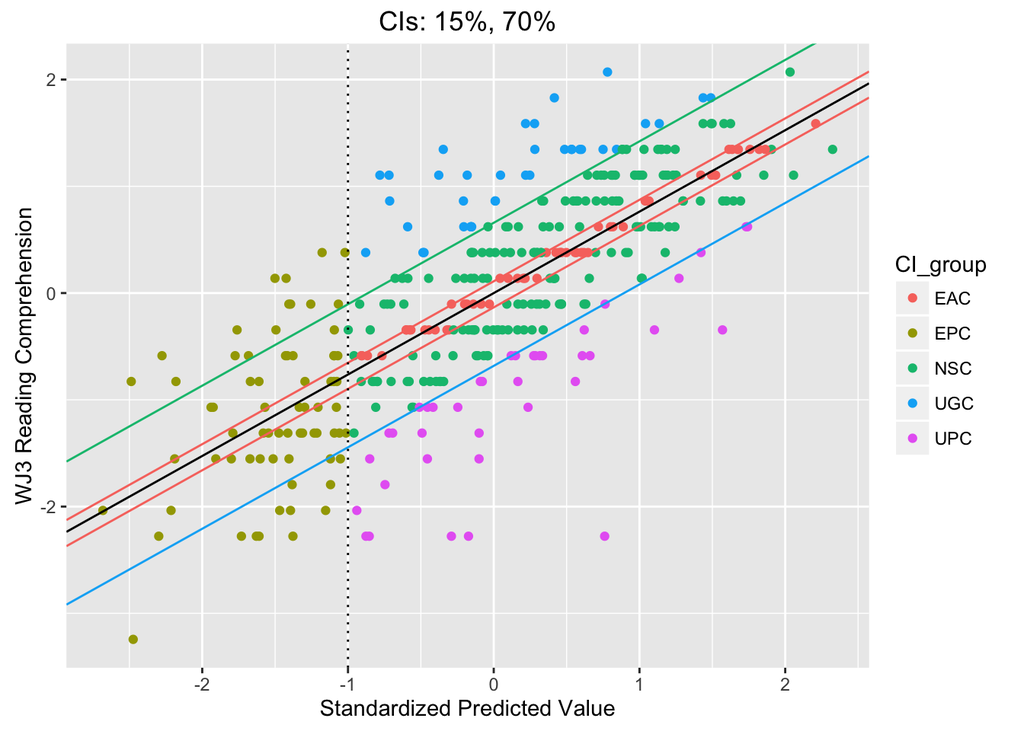

```r
print(p1)
```

```r
RLM.WV <- data.frame(table(rlmwv.cc$CI_group, rlmwv.cc$handedness))
names(RLM.WV) <- c("Group", "handedness", "rlm.wasi.vocab")
RLM.WV.r <- RLM.WV[RLM.WV$handedness == "right",]
RLM.WV.r <- RLM.WV.r[,-2]
```

## Robust Model with PPVT

Run model, get groups.

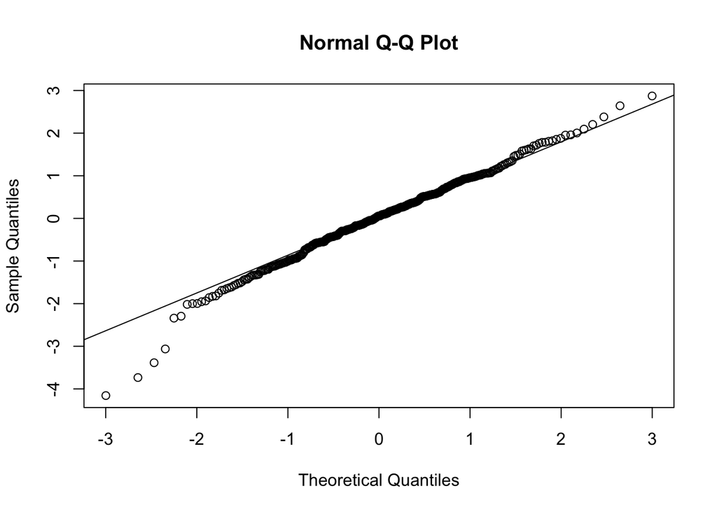

```r
model.data.rlmpp <- data[, c(1, 2, 18, 7, 5, 19, 11)]
rlmpp.cc <- model.data.rlmpp[complete.cases(model.data.rlmpp),]

# center and scale predictors
rlmpp.cc$wasi.matr.cs <- scale(rlmpp.cc$wasi.matr.raw)
rlmpp.cc$ppvt.cs <- scale(rlmpp.cc$ppvt.raw)
rlmpp.cc$wj3.rcomp.cs <- scale(rlmpp.cc$wj3.rcomp.raw)

# center age
rlmpp.cc$age.c <- rlmpp.cc$age - mean(rlmpp.cc$age, na.rm = TRUE)
# composite has already been scaled

### Run regression
m1 <- rlm(wj3.rcomp.cs ~ age.c + decoding.comp + wasi.matr.cs + ppvt.cs, data = rlmpp.cc, method = "MM")

#standardize predicted values
rlmpp.cc$Pred <- predict(m1)
rlmpp.cc$stdPred <- scale(rlmpp.cc$Pred)

#obtained residuals
rlmpp.cc$resid <- resid <- residuals(m1)
qqnorm(scale(resid)); qqline(scale(resid))
```

```r
#create the range of SD (z value) bins
my.bin <- c(range(scale(resid))+.1, ci2z(ci.to.use), -ci2z(ci.to.use))
#we could also manually specify in terms of SDs
# my.bin <- c(-3, -1, -.25, .25, 1, 3)
my.bin <- sort(my.bin)
# names for each bin specified above
grouping <- c("UPC", "NSC", "EAC", "NSC", "UGC")

rlmpp.cc$CI_group <- grouping[findInterval(scale(resid), vec=my.bin, all.inside=T)]
#those with Standardized Predicted Value below -1 should be "EPC"
rlmpp.cc$CI_group[rlmpp.cc$stdPred < -1] <- "EPC"

### there are five groups c("EAC", "NSC", "UGC", "UPC", "EPC")
### so the argument n = 5
my.col <- gg_color_hue(n=5)

## unscale the z value for each CI, so I can add that value to intercept
unscale.ci <- my.bin[-c(1,length(my.bin))]*sd(resid)+mean(resid)

## create plot
m2 <- lm(wj3.rcomp.cs ~ stdPred, data=rlmpp.cc)

p1 <- ggplot(rlmpp.cc, aes(x=stdPred, y=wj3.rcomp.cs)) + geom_point(aes(color=CI_group)) +
  geom_abline(intercept = coef(m2)[1], slope = coef(m2)[2]) +
  geom_abline(intercept = coef(m2)[1] + unscale.ci[2], slope = coef(m2)[2], color=my.col[1]) +
  geom_abline(intercept = coef(m2)[1] + unscale.ci[3], slope = coef(m2)[2], color=my.col[1]) +
  geom_abline(intercept = coef(m2)[1] + unscale.ci[1], slope = coef(m2)[2], color=my.col[4]) +
  geom_abline(intercept = coef(m2)[1] + unscale.ci[4], slope = coef(m2)[2], color=my.col[3]) +
  geom_vline(xintercept = -1, lty="dotted") +
  xlab("Standardized Predicted Value")+ylab("WJ3 Reading Comprehension") +
  ggtitle(ci.title)
```

## Group Differences RLM2

Robust Model with PPVT

```r
# take away NSC group
rlmpp.cc2 <- subset(rlmpp.cc, CI_group != "NSC")
rlmpp.cc2$CI_group <- as.factor(rlmpp.cc2$CI_group)
```

### Reading Comprehension

```r
a1 <- aov(wj3.rcomp.cs ~ CI_group, data = rlmpp.cc2)
summary(a1)
```

```
##              Df Sum Sq Mean Sq F value Pr(>F)
## CI_group      3 170.49   56.83   165.1 <2e-16 ***
## Residuals   192  66.09    0.34
## ---
## Signif. codes:  0 '***' 0.001 '**' 0.01 '*' 0.05 '.' 0.1 ' ' 1
```

```r
pairwise.t.test(rlmpp.cc2$wj3.rcomp.cs, rlmpp.cc2$CI_group, p.adjust.method = "bonferroni")
```

```
##
##  Pairwise comparisons using t tests with pooled SD
##
## data:  rlmpp.cc2$wj3.rcomp.cs and rlmpp.cc2$CI_group
##
##     EAC     EPC     UGC
## EPC < 2e-16 -       -
## UGC 6.7e-11 < 2e-16 -
## UPC < 2e-16 0.0028  < 2e-16
##
## P value adjustment method: bonferroni
```

```r
aggregate(rlmpp.cc2$wj3.rcomp.cs, list(rlmpp.cc2$CI_group), mean)
```

```
##   Group.1         V1
## 1     EAC  0.3046716
## 2     EPC -1.2777743
## 3     UGC  1.2445933
## 4     UPC -0.8724662
```

### Age

```r
a1 <- aov(age.c ~ CI_group, data = rlmpp.cc2)
summary(a1)
```

```
##              Df Sum Sq Mean Sq F value Pr(>F)
## CI_group      3   65.1  21.684    2.49 0.0616 .
## Residuals   192 1671.7   8.707
## ---
## Signif. codes:  0 '***' 0.001 '**' 0.01 '*' 0.05 '.' 0.1 ' ' 1
```

```r
pairwise.t.test(rlmpp.cc2$age.c, rlmpp.cc2$CI_group, p.adjust.method = "bonferroni")
```

```
##
##  Pairwise comparisons using t tests with pooled SD
##
## data:  rlmpp.cc2$age.c and rlmpp.cc2$CI_group
##
##     EAC  EPC  UGC
## EPC 0.96 -    -
## UGC 1.00 0.17 -
## UPC 1.00 0.12 1.00
##
## P value adjustment method: bonferroni
```

```r
aggregate(rlmpp.cc2$age.c, list(rlmpp.cc2$CI_group), mean)
```

```
##   Group.1          x
## 1     EAC -0.3964170
## 2     EPC -1.1662882
## 3     UGC  0.2518420
## 4     UPC  0.1769417
```

### Matrix Reasoning

```r
a1 <- aov(wasi.matr.cs ~ CI_group, data = rlmpp.cc2)
summary(a1)
```

```
##              Df Sum Sq Mean Sq F value Pr(>F)
## CI_group      3  83.89  27.963   44.94 <2e-16 ***
## Residuals   192 119.48   0.622
## ---
## Signif. codes:  0 '***' 0.001 '**' 0.01 '*' 0.05 '.' 0.1 ' ' 1
```

```r
pairwise.t.test(rlmpp.cc2$wasi.matr.cs, rlmpp.cc2$CI_group, p.adjust.method = "bonferroni")
```

```
##
##  Pairwise comparisons using t tests with pooled SD
##
## data:  rlmpp.cc2$wasi.matr.cs and rlmpp.cc2$CI_group
##
##     EAC     EPC     UGC
## EPC < 2e-16 -       -
## UGC 1.00    7.8e-15 -
## UPC 0.11    2.0e-11 0.28
##
## P value adjustment method: bonferroni
```

```r
aggregate(rlmpp.cc2$wasi.matr.cs, list(rlmpp.cc2$CI_group), mean)
```

```
##   Group.1          V1
## 1     EAC  0.35433821
## 2     EPC -1.15346489
## 3     UGC  0.34826446
## 4     UPC -0.01484232
```

### Decoding

```r
a1 <- aov(decoding.comp ~ CI_group, data = rlmpp.cc2)
summary(a1)
```

```
##              Df Sum Sq Mean Sq F value Pr(>F)
## CI_group      3  81.91  27.302   45.79 <2e-16 ***
## Residuals   192 114.47   0.596
## ---
## Signif. codes:  0 '***' 0.001 '**' 0.01 '*' 0.05 '.' 0.1 ' ' 1
```

```r
pairwise.t.test(rlmpp.cc2$decoding.comp, rlmpp.cc2$CI_group, p.adjust.method = "bonferroni")
```

```
##
##  Pairwise comparisons using t tests with pooled SD
##
## data:  rlmpp.cc2$decoding.comp and rlmpp.cc2$CI_group
##
##     EAC     EPC     UGC
## EPC < 2e-16 -       -
## UGC 1.00    5.4e-13 -
## UPC 0.91    3.0e-14 1.00
##
## P value adjustment method: bonferroni
```

```r
aggregate(rlmpp.cc2$decoding.comp, list(rlmpp.cc2$CI_group), mean)
```

```
##   Group.1          x
## 1     EAC  0.3990126
## 2     EPC -1.0960636
## 3     UGC  0.2588305
## 4     UPC  0.1792043
```

### PPVT

```r
a1 <- aov(ppvt.cs ~ CI_group, data = rlmpp.cc2)
summary(a1)
```

```
##              Df Sum Sq Mean Sq F value Pr(>F)
## CI_group      3 187.65   62.55   190.7 <2e-16 ***
## Residuals   192  62.96    0.33
## ---
## Signif. codes:  0 '***' 0.001 '**' 0.01 '*' 0.05 '.' 0.1 ' ' 1
```

```r
pairwise.t.test(rlmpp.cc2$ppvt.cs, rlmpp.cc2$CI_group, p.adjust.method = "bonferroni")
```

```
##
##  Pairwise comparisons using t tests with pooled SD
##
## data:  rlmpp.cc2$ppvt.cs and rlmpp.cc2$CI_group
##
##     EAC    EPC    UGC
## EPC <2e-16 -      -
## UGC 1.00   <2e-16 -
## UPC 0.30   <2e-16 0.52
##
## P value adjustment method: bonferroni
```

```r
aggregate(rlmpp.cc2$ppvt.cs, list(rlmpp.cc2$CI_group), mean)
```

```
##   Group.1         V1
## 1     EAC  0.3959796
## 2     EPC -1.7857224
## 3     UGC  0.3984613
## 4     UPC  0.1730397
```

Show group sizes, plot.

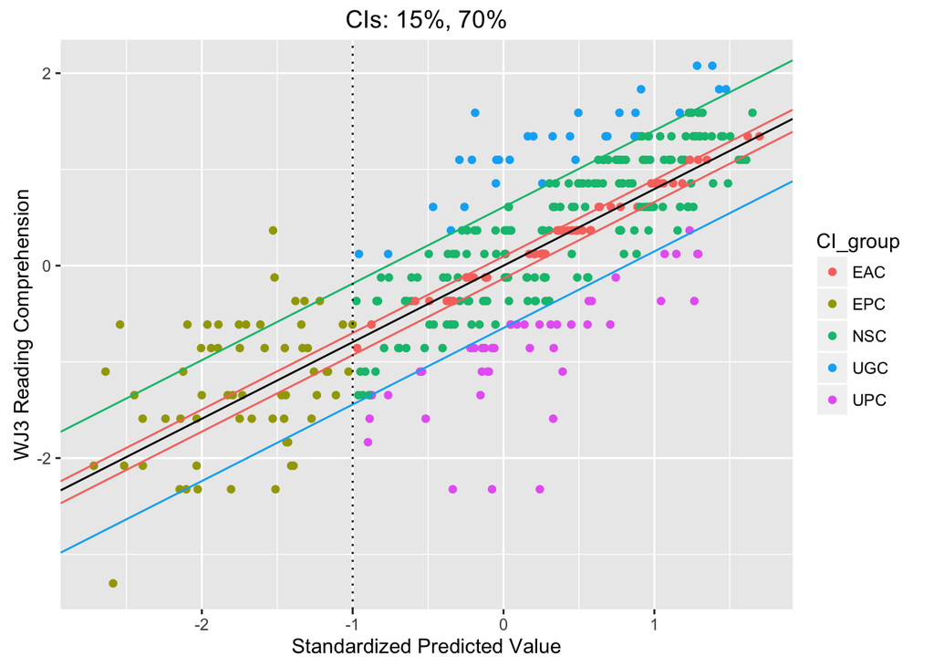

```r
print(p1)
```

```r
RLM.PP <- data.frame(table(rlmpp.cc$CI_group, rlmpp.cc$handedness))
names(RLM.PP) <- c("Group", "handedness", "rlm.ppvt")
RLM.PP.r <- RLM.PP[RLM.PP$handedness == "right",]
RLM.PP.r <- RLM.PP.r[,-2]
```

## Robust Model with Vocab Composite

Run model, get groups.

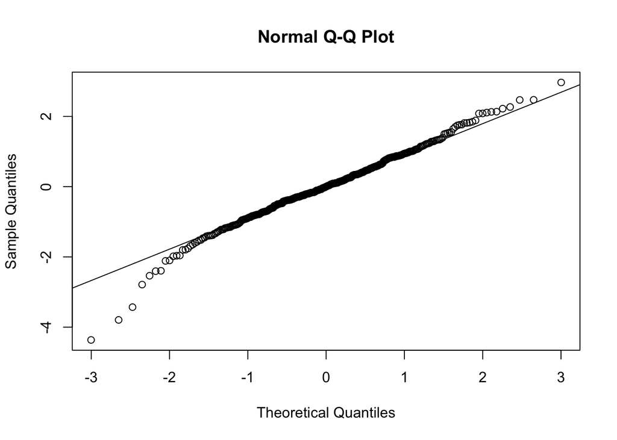

```r
model.data.rlmvc <- data[, c(1, 2, 18, 7, 20, 19, 11)]
rlmvc.cc <- model.data.rlmvc[complete.cases(model.data.rlmvc),]

# center and scale predictors
rlmvc.cc$wasi.matr.cs <- scale(rlmvc.cc$wasi.matr.raw)
rlmvc.cc$wj3.rcomp.cs <- scale(rlmvc.cc$wj3.rcomp.raw)

# center age
rlmvc.cc$age.c <- rlmvc.cc$age - mean(rlmvc.cc$age, na.rm = TRUE)
# composites have already been scaled

### Run regression
m1 <- rlm(wj3.rcomp.cs ~ age.c + decoding.comp + wasi.matr.cs + vocab.comp, data = rlmvc.cc, method = "MM")

#standardize predicted values
rlmvc.cc$Pred <- predict(m1)
rlmvc.cc$stdPred <- scale(rlmvc.cc$Pred)

#obtained residuals
rlmvc.cc$resid <- resid <- residuals(m1)
qqnorm(scale(resid)); qqline(scale(resid))
```

```r
#create the range of SD (z value) bins
my.bin <- c(range(scale(resid))+.1, ci2z(ci.to.use), -ci2z(ci.to.use))
#we could also manually specify in terms of SDs
# my.bin <- c(-3, -1, -.25, .25, 1, 3)
my.bin <- sort(my.bin)
# names for each bin specified above
grouping <- c("UPC", "NSC", "EAC", "NSC", "UGC")

rlmvc.cc$CI_group <- grouping[findInterval(scale(resid), vec=my.bin, all.inside=T)]
#those with Standardized Predicted Value below -1 should be "EPC"
rlmvc.cc$CI_group[rlmvc.cc$stdPred < -1] <- "EPC"

### there are five groups c("EAC", "NSC", "UGC", "UPC", "EPC")
### so the argument n = 5
my.col <- gg_color_hue(n=5)

## unscale the z value for each CI, so I can add that value to intercept
unscale.ci <- my.bin[-c(1,length(my.bin))]*sd(resid)+mean(resid)

## create plot
m2 <- lm(wj3.rcomp.cs ~ stdPred, data=rlmvc.cc)

p1 <- ggplot(rlmvc.cc, aes(x=stdPred, y=wj3.rcomp.cs)) + geom_point(aes(color=CI_group)) +
  geom_abline(intercept = coef(m2)[1], slope = coef(m2)[2]) +
  geom_abline(intercept = coef(m2)[1] + unscale.ci[2], slope = coef(m2)[2], color=my.col[1]) +
  geom_abline(intercept = coef(m2)[1] + unscale.ci[3], slope = coef(m2)[2], color=my.col[1]) +
  geom_abline(intercept = coef(m2)[1] + unscale.ci[1], slope = coef(m2)[2], color=my.col[4]) +
  geom_abline(intercept = coef(m2)[1] + unscale.ci[4], slope = coef(m2)[2], color=my.col[3]) +
  geom_vline(xintercept = -1, lty="dotted") +
  xlab("Standardized Predicted Value")+ylab("WJ3 Reading Comprehension") +
  ggtitle(ci.title)
```

## Group Differences RLM3

Robust Model with Vocab Composite

```r
# take away NSC group
rlmvc.cc2 <- subset(rlmvc.cc, CI_group != "NSC")
rlmvc.cc2$CI_group <- as.factor(rlmvc.cc2$CI_group)
```

### Reading Comprehension

```r
a1 <- aov(wj3.rcomp.cs ~ CI_group, data = rlmvc.cc2)
summary(a1)
```

```
##              Df Sum Sq Mean Sq F value Pr(>F)
## CI_group      3 152.07   50.69   122.1 <2e-16 ***
## Residuals   196  81.38    0.42
## ---
## Signif. codes:  0 '***' 0.001 '**' 0.01 '*' 0.05 '.' 0.1 ' ' 1
```

```r
pairwise.t.test(rlmvc.cc2$wj3.rcomp.cs, rlmvc.cc2$CI_group, p.adjust.method = "bonferroni")
```

```
##
##  Pairwise comparisons using t tests with pooled SD
##
## data:  rlmvc.cc2$wj3.rcomp.cs and rlmvc.cc2$CI_group
##
##     EAC     EPC     UGC
## EPC < 2e-16 -       -
## UGC 0.00018 < 2e-16 -
## UPC < 2e-16 0.09582 < 2e-16
##
## P value adjustment method: bonferroni
```

```r
aggregate(rlmvc.cc2$wj3.rcomp.cs, list(rlmvc.cc2$CI_group), mean)
```

```
##   Group.1         V1
## 1     EAC  0.3794964
## 2     EPC -1.1973313
## 3     UGC  0.9762832
## 4     UPC -0.8805149
```

### Age

```r
a1 <- aov(age.c ~ CI_group, data = rlmvc.cc2)
summary(a1)
```

```
##              Df Sum Sq Mean Sq F value Pr(>F)
## CI_group      3   86.5  28.842   3.484 0.0169 *
## Residuals   196 1622.5   8.278
## ---
## Signif. codes:  0 '***' 0.001 '**' 0.01 '*' 0.05 '.' 0.1 ' ' 1
```

```r
pairwise.t.test(rlmvc.cc2$age.c, rlmvc.cc2$CI_group, p.adjust.method = "bonferroni")
```

```
##
##  Pairwise comparisons using t tests with pooled SD
##
## data:  rlmvc.cc2$age.c and rlmvc.cc2$CI_group
##
##     EAC   EPC   UGC
## EPC 0.014 -     -
## UGC 1.000 0.242 -
## UPC 1.000 0.710 1.000
##
## P value adjustment method: bonferroni
```

```r
aggregate(rlmvc.cc2$age.c, list(rlmvc.cc2$CI_group), mean)
```

```
##   Group.1          x
## 1     EAC  0.4343333
## 2     EPC -1.1341097
## 3     UGC  0.1014540
## 4     UPC -0.2213282
```

### Matrix Reasoning

```r
a1 <- aov(wasi.matr.cs ~ CI_group, data = rlmvc.cc2)
summary(a1)
```

```
##              Df Sum Sq Mean Sq F value Pr(>F)
## CI_group      3  87.18  29.058   43.51 <2e-16 ***
## Residuals   196 130.89   0.668
## ---
## Signif. codes:  0 '***' 0.001 '**' 0.01 '*' 0.05 '.' 0.1 ' ' 1
```

```r
pairwise.t.test(rlmvc.cc2$wasi.matr.cs, rlmvc.cc2$CI_group, p.adjust.method = "bonferroni")
```

```
##
##  Pairwise comparisons using t tests with pooled SD
##
## data:  rlmvc.cc2$wasi.matr.cs and rlmvc.cc2$CI_group
##
##     EAC     EPC     UGC
## EPC < 2e-16 -       -
## UGC 0.82    1.8e-11 -
## UPC 0.13    6.0e-10 1.00
##
## P value adjustment method: bonferroni
```

```r
aggregate(rlmvc.cc2$wasi.matr.cs, list(rlmvc.cc2$CI_group), mean)
```

```
##   Group.1           V1
## 1     EAC  0.408337186
## 2     EPC -1.122059781
## 3     UGC  0.143994332
## 4     UPC  0.008109819
```

### Decoding

```r
a1 <- aov(decoding.comp ~ CI_group, data = rlmvc.cc2)
summary(a1)
```

```
##              Df Sum Sq Mean Sq F value Pr(>F)
## CI_group      3  91.27  30.422   52.79 <2e-16 ***
## Residuals   196 112.95   0.576
## ---
## Signif. codes:  0 '***' 0.001 '**' 0.01 '*' 0.05 '.' 0.1 ' ' 1
```

```r
pairwise.t.test(rlmvc.cc2$decoding.comp, rlmvc.cc2$CI_group, p.adjust.method = "bonferroni")
```

```
##
##  Pairwise comparisons using t tests with pooled SD
##
## data:  rlmvc.cc2$decoding.comp and rlmvc.cc2$CI_group
##
##     EAC     EPC     UGC
## EPC < 2e-16 -       -
## UGC 0.31    1.3e-11 -
## UPC 1.00    5.0e-16 1.00
##
## P value adjustment method: bonferroni
```

```r
aggregate(rlmvc.cc2$decoding.comp, list(rlmvc.cc2$CI_group), mean)
```

```
##   Group.1           x
## 1     EAC  0.41566955
## 2     EPC -1.08955316
## 3     UGC  0.09433047
## 4     UPC  0.31312309
```

### Vocab Composite

```r
a1 <- aov(vocab.comp ~ CI_group, data = rlmvc.cc2)
summary(a1)
```

```
##              Df Sum Sq Mean Sq F value Pr(>F)
## CI_group      3 134.52   44.84   135.8 <2e-16 ***
## Residuals   196  64.73    0.33
## ---
## Signif. codes:  0 '***' 0.001 '**' 0.01 '*' 0.05 '.' 0.1 ' ' 1
```

```r
pairwise.t.test(rlmvc.cc2$vocab.comp, rlmvc.cc2$CI_group, p.adjust.method = "bonferroni")
```

```
##
##  Pairwise comparisons using t tests with pooled SD
##
## data:  rlmvc.cc2$vocab.comp and rlmvc.cc2$CI_group
##
##     EAC    EPC    UGC
## EPC <2e-16 -      -
## UGC 0.0024 <2e-16 -
## UPC 0.1024 <2e-16 1.0000
##
## P value adjustment method: bonferroni
```

```r
aggregate(rlmvc.cc2$vocab.comp, list(rlmvc.cc2$CI_group), mean)
```

```
##   Group.1           x
## 1     EAC  0.48404954
## 2     EPC -1.39800664
## 3     UGC  0.03561827
## 4     UPC  0.19215485
```

Show group sizes, plot.

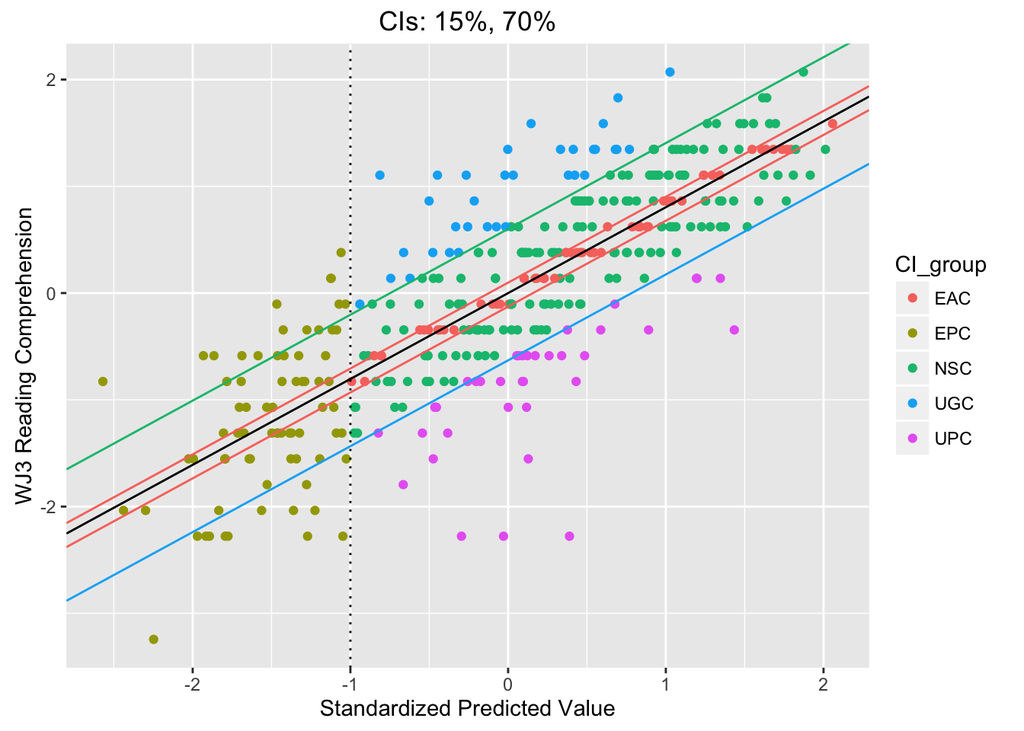

```r
print(p1)
```

```r
RLM.VC <- data.frame(table(rlmvc.cc$CI_group, rlmvc.cc$handedness))
names(RLM.VC) <- c("Group", "handedness", "rlm.ppvt")
RLM.VC.r <- RLM.VC[RLM.VC$handedness == "right",]
RLM.VC.r <- RLM.VC.r[,-2]
```

## Robust Model with Oral Comprehension

Run model, get groups.

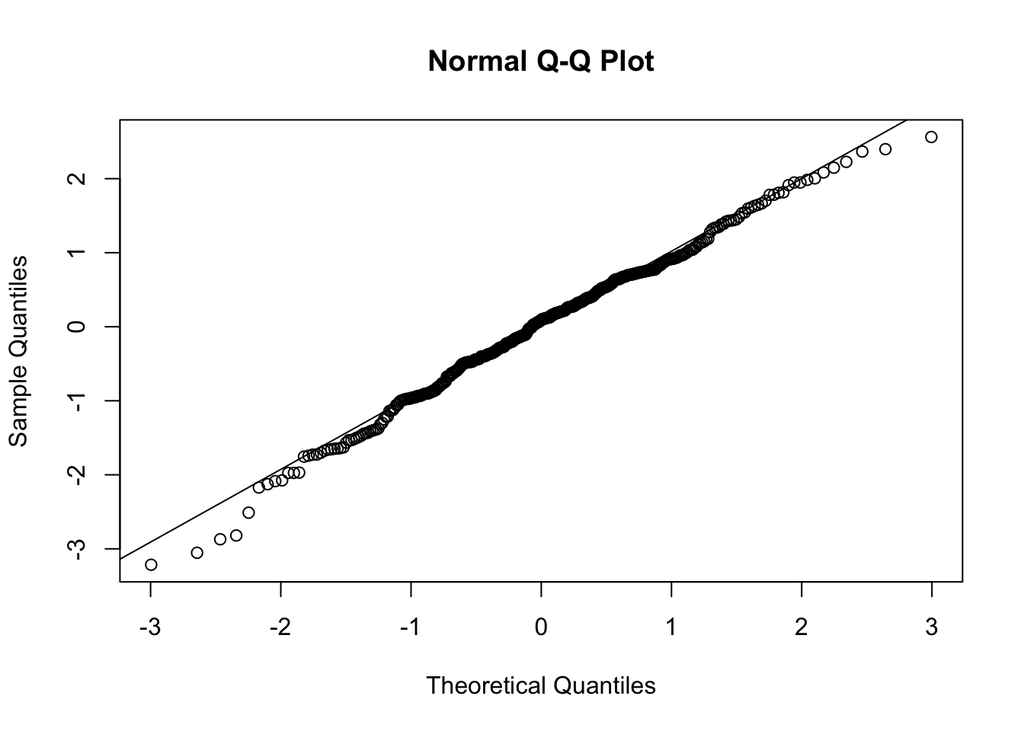

```r
model.data.rlmoc <- data[, c(1, 2, 18, 7, 12, 19, 11)]
rlmoc.cc <- model.data.rlmoc[complete.cases(model.data.rlmoc),]

# center and scale predictors
rlmoc.cc$wasi.matr.cs <- scale(rlmoc.cc$wasi.matr.raw)
rlmoc.cc$wj3.rcomp.cs <- scale(rlmoc.cc$wj3.rcomp.raw)
rlmoc.cc$wj3.oralcomp.cs <- scale(rlmoc.cc$wj3.oralcomp.raw)

# center age
rlmoc.cc$age.c <- rlmoc.cc$age - mean(rlmoc.cc$age, na.rm = TRUE)
# composites have already been scaled

### Run regression
m1 <- rlm(wj3.rcomp.cs ~ age.c + decoding.comp + wasi.matr.cs + wj3.oralcomp.cs, data = rlmoc.cc, method = "MM")

#standardize predicted values
rlmoc.cc$Pred <- predict(m1)
rlmoc.cc$stdPred <- scale(rlmoc.cc$Pred)

#obtained residuals
rlmoc.cc$resid <- resid <- residuals(m1)
qqnorm(scale(resid)); qqline(scale(resid))
```

```r
#create the range of SD (z value) bins
my.bin <- c(range(scale(resid))+.1, ci2z(ci.to.use), -ci2z(ci.to.use))
#we could also manually specify in terms of SDs
# my.bin <- c(-3, -1, -.25, .25, 1, 3)
my.bin <- sort(my.bin)
# names for each bin specified above
grouping <- c("UPC", "NSC", "EAC", "NSC", "UGC")

rlmoc.cc$CI_group <- grouping[findInterval(scale(resid), vec=my.bin, all.inside=T)]
#those with Standardized Predicted Value below -1 should be "EPC"
rlmoc.cc$CI_group[rlmoc.cc$stdPred < -1] <- "EPC"

### there are five groups c("EAC", "NSC", "UGC", "UPC", "EPC")
### so the argument n = 5
my.col <- gg_color_hue(n=5)

## unscale the z value for each CI, so I can add that value to intercept
unscale.ci <- my.bin[-c(1,length(my.bin))]*sd(resid)+mean(resid)

## create plot
m2 <- lm(wj3.rcomp.cs ~ stdPred, data=rlmoc.cc)

p1 <- ggplot(rlmoc.cc, aes(x=stdPred, y=wj3.rcomp.cs)) + geom_point(aes(color=CI_group)) +
  geom_abline(intercept = coef(m2)[1], slope = coef(m2)[2]) +
  geom_abline(intercept = coef(m2)[1] + unscale.ci[2], slope = coef(m2)[2], color=my.col[1]) +
  geom_abline(intercept = coef(m2)[1] + unscale.ci[3], slope = coef(m2)[2], color=my.col[1]) +
  geom_abline(intercept = coef(m2)[1] + unscale.ci[1], slope = coef(m2)[2], color=my.col[4]) +
  geom_abline(intercept = coef(m2)[1] + unscale.ci[4], slope = coef(m2)[2], color=my.col[3]) +
  geom_vline(xintercept = -1, lty="dotted") +
  xlab("Standardized Predicted Value")+ylab("WJ3 Reading Comprehension") +
  ggtitle(ci.title)
```

## Group Differences RLM4

Robust Model with Oral Comprehension

```r
# take away NSC group
rlmoc.cc2 <- subset(rlmoc.cc, CI_group != "NSC")
rlmoc.cc2$CI_group <- as.factor(rlmoc.cc2$CI_group)
```

### Reading Comprehension

```r
a1 <- aov(wj3.rcomp.cs ~ CI_group, data = rlmoc.cc2)
summary(a1)
```

```
##              Df Sum Sq Mean Sq F value Pr(>F)
## CI_group      3 154.35   51.45   122.9 <2e-16 ***
## Residuals   182  76.22    0.42
## ---
## Signif. codes:  0 '***' 0.001 '**' 0.01 '*' 0.05 '.' 0.1 ' ' 1
```

```r
pairwise.t.test(rlmoc.cc2$wj3.rcomp.cs, rlmoc.cc2$CI_group, p.adjust.method = "bonferroni")
```

```
##
##  Pairwise comparisons using t tests with pooled SD
##
## data:  rlmoc.cc2$wj3.rcomp.cs and rlmoc.cc2$CI_group
##
##     EAC     EPC     UGC
## EPC < 2e-16 -       -
## UGC 9.7e-07 < 2e-16 -
## UPC 3.9e-14 0.028   < 2e-16
##
## P value adjustment method: bonferroni
```

```r
aggregate(rlmoc.cc2$wj3.rcomp.cs, list(rlmoc.cc2$CI_group), mean)
```

```
##   Group.1         V1
## 1     EAC  0.3240570
## 2     EPC -1.2265945
## 3     UGC  1.1287805
## 4     UPC -0.8579839
```

### Age

```r
a1 <- aov(age.c ~ CI_group, data = rlmoc.cc2)
summary(a1)
```

```
##              Df Sum Sq Mean Sq F value Pr(>F)
## CI_group      3   63.2  21.066   2.709 0.0466 *
## Residuals   182 1415.3   7.776
## ---
## Signif. codes:  0 '***' 0.001 '**' 0.01 '*' 0.05 '.' 0.1 ' ' 1
```

```r
pairwise.t.test(rlmoc.cc2$age.c, rlmoc.cc2$CI_group, p.adjust.method = "bonferroni")
```

```
##
##  Pairwise comparisons using t tests with pooled SD
##
## data:  rlmoc.cc2$age.c and rlmoc.cc2$CI_group
##
##     EAC  EPC  UGC
## EPC 0.14 -    -
## UGC 1.00 0.22 -
## UPC 1.00 0.21 1.00
##
## P value adjustment method: bonferroni
```

```r
aggregate(rlmoc.cc2$age.c, list(rlmoc.cc2$CI_group), mean)
```

```
##   Group.1           x
## 1     EAC  0.06418642
## 2     EPC -1.16025363
## 3     UGC  0.09323122
## 4     UPC  0.01987571
```

### Matrix Reasoning

```r
a1 <- aov(wasi.matr.cs ~ CI_group, data = rlmoc.cc2)
summary(a1)
```

```
##              Df Sum Sq Mean Sq F value Pr(>F)
## CI_group      3   78.8  26.268   40.33 <2e-16 ***
## Residuals   182  118.5   0.651
## ---
## Signif. codes:  0 '***' 0.001 '**' 0.01 '*' 0.05 '.' 0.1 ' ' 1
```

```r
pairwise.t.test(rlmoc.cc2$wasi.matr.cs, rlmoc.cc2$CI_group, p.adjust.method = "bonferroni")
```

```
##
##  Pairwise comparisons using t tests with pooled SD
##
## data:  rlmoc.cc2$wasi.matr.cs and rlmoc.cc2$CI_group
##
##     EAC     EPC     UGC
## EPC 1.9e-15 -       -
## UGC 1       5.4e-14 -
## UPC 1       9.9e-12 1
##
## P value adjustment method: bonferroni
```

```r
aggregate(rlmoc.cc2$wasi.matr.cs, list(rlmoc.cc2$CI_group), mean)
```

```
##   Group.1          V1
## 1     EAC  0.20077433
## 2     EPC -1.19309458
## 3     UGC  0.26151715
## 4     UPC  0.02419314
```

### Decoding

```r
a1 <- aov(decoding.comp ~ CI_group, data = rlmoc.cc2)
summary(a1)
```

```
##              Df Sum Sq Mean Sq F value Pr(>F)
## CI_group      3  89.19  29.731   47.02 <2e-16 ***
## Residuals   182 115.08   0.632
## ---
## Signif. codes:  0 '***' 0.001 '**' 0.01 '*' 0.05 '.' 0.1 ' ' 1
```

```r
pairwise.t.test(rlmoc.cc2$decoding.comp, rlmoc.cc2$CI_group, p.adjust.method = "bonferroni")
```

```
##
##  Pairwise comparisons using t tests with pooled SD
##
## data:  rlmoc.cc2$decoding.comp and rlmoc.cc2$CI_group
##
##     EAC     EPC     UGC
## EPC < 2e-16 -       -
## UGC 1       1.3e-12 -
## UPC 1       3.2e-15 1
##
## P value adjustment method: bonferroni
```

```r
aggregate(rlmoc.cc2$decoding.comp, list(rlmoc.cc2$CI_group), mean)
```

```
##   Group.1          x
## 1     EAC  0.3974267
## 2     EPC -1.1414203
## 3     UGC  0.2029380
## 4     UPC  0.2671875
```

### Oral Comprehension

```r
a1 <- aov(wj3.oralcomp.cs ~ CI_group, data = rlmoc.cc2)
summary(a1)
```

```
##              Df Sum Sq Mean Sq F value Pr(>F)
## CI_group      3 138.51   46.17   94.76 <2e-16 ***
## Residuals   182  88.68    0.49
## ---
## Signif. codes:  0 '***' 0.001 '**' 0.01 '*' 0.05 '.' 0.1 ' ' 1
```

```r
pairwise.t.test(rlmoc.cc2$wj3.oralcomp.cs, rlmoc.cc2$CI_group, p.adjust.method = "bonferroni")
```

```
##
##  Pairwise comparisons using t tests with pooled SD
##
## data:  rlmoc.cc2$wj3.oralcomp.cs and rlmoc.cc2$CI_group
##
##     EAC    EPC    UGC
## EPC <2e-16 -      -
## UGC 1.00   <2e-16 -
## UPC 0.38   <2e-16 1.00
##
## P value adjustment method: bonferroni
```

```r
aggregate(rlmoc.cc2$wj3.oralcomp.cs, list(rlmoc.cc2$CI_group), mean)
```

```
##   Group.1         V1
## 1     EAC  0.4133190
## 2     EPC -1.5122922
## 3     UGC  0.2769300
## 4     UPC  0.1334295
```

Show group sizes, plot.

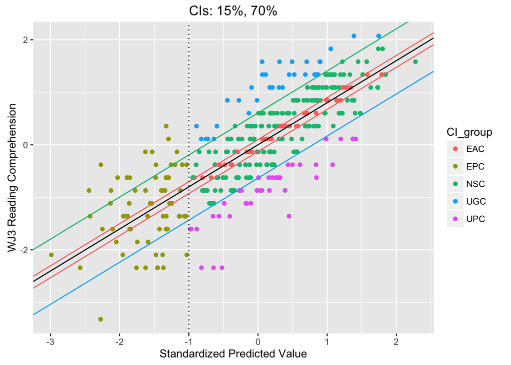

```r
print(p1)
```

```r
RLM.OC <- data.frame(table(rlmoc.cc$CI_group, rlmoc.cc$handedness))
names(RLM.OC) <- c("Group", "handedness", "rlm.ppvt")
RLM.OC.r <- RLM.OC[RLM.OC$handedness == "right",]
RLM.OC.r <- RLM.OC.r[,-2]
```

## Group Sizes

Across analyses

```r
group.sizes <- cbind(LM.WASI.Vocab.r, LM.PPVT.r[,2], LM.VC.r[,2], LM.OC.r[,2], RLM.WV.r[,2], RLM.PP.r[,2], RLM.VC.r[,2], RLM.OC.r[,2])
names(group.sizes) <- c("group", "LM1 (WASI Vocab)", "LM2 (PPVT)", "LM3 (Vocab Composite)", "LM4 (Oral Comp)", "RLM1 (WASI Vocab)", "RLM2 (PPVT)", "RLM3 (Vocab Composite)", "RLM4 (Oral Comp)")
gs <- xtable(group.sizes)
print(gs, type ="html", include.rownames = FALSE)
```

| group | LM1 (WASI Vocab) | LM2 (PPVT) | LM3 (Vocab Composite) | LM4 (Oral Comp) | RLM1 (WASI Vocab) | RLM2 (PPVT) | RLM3 (Vocab Composite) | RLM4 (Oral Comp) |
| --- | --- | --- | --- | --- | --- | --- | --- | --- |
| EAC | 42 | 42 | 44 | 36 | 44 | 49 | 47 | 38 |
| EPC | 58 | 57 | 62 | 56 | 56 | 51 | 61 | 55 |
| NSC | 147 | 140 | 143 | 146 | 153 | 148 | 150 | 151 |
| UGC | 35 | 34 | 34 | 31 | 32 | 26 | 28 | 28 |
| UPC | 35 | 41 | 34 | 40 | 32 | 40 | 31 | 37 |